# R Notebook

1)reading the dataset

```r
hcdsd=read.csv("C:/Users/prabh/Downloads/healthcare-dataset-stroke-data (1).csv",stringsAsFactors = TRUE)
hcdsd
```

| id | gender | age | hypertension | heart_disease | ever_married | work_type | Residence_type | avg_glucose_level | bmi | smoking_status | stroke |
| --- | --- | --- | --- | --- | --- | --- | --- | --- | --- | --- | --- |
| 9046 | Male | 67.00 | 0 | 1 | Yes | Private | Urban | 228.69 | 36.6 | formerly smoked | 1 |
| 51676 | Female | 61.00 | 0 | 0 | Yes | Self-employed | Rural | 202.21 | NA | never smoked | 1 |
| 31112 | Male | 80.00 | 0 | 1 | Yes | Private | Rural | 105.92 | 32.5 | never smoked | 1 |
| 60182 | Female | 49.00 | 0 | 0 | Yes | Private | Urban | 171.23 | 34.4 | smokes | 1 |
| 1665 | Female | 79.00 | 1 | 0 | Yes | Self-employed | Rural | 174.12 | 24.0 | never smoked | 1 |
| 56669 | Male | 81.00 | 0 | 0 | Yes | Private | Urban | 186.21 | 29.0 | formerly smoked | 1 |
| 53882 | Male | 74.00 | 1 | 1 | Yes | Private | Rural | 70.09 | 27.4 | never smoked | 1 |
| 10434 | Female | 69.00 | 0 | 0 | No | Private | Urban | 94.39 | 22.8 | never smoked | 1 |
| 27419 | Female | 59.00 | 0 | 0 | Yes | Private | Rural | 76.15 | NA | Unknown | 1 |
| 60491 | Female | 78.00 | 0 | 0 | Yes | Private | Urban | 58.57 | 24.2 | Unknown | 1 |

[output cut: 990 more lines]

as id is unique, let’s remove “id” variable

```r
hcdsd$id=NULL
```

Let’s see the structure and summary of the dataset

```r
str(hcdsd)
```

```
'data.frame':   5110 obs. of  11 variables:
 $ gender           : Factor w/ 3 levels "Female","Male",..: 2 1 2 1 1 2 2 1 1 1 ...
 $ age              : num  67 61 80 49 79 81 74 69 59 78 ...
 $ hypertension     : int  0 0 0 0 1 0 1 0 0 0 ...
 $ heart_disease    : int  1 0 1 0 0 0 1 0 0 0 ...
 $ ever_married     : Factor w/ 2 levels "No","Yes": 2 2 2 2 2 2 2 1 2 2 ...
 $ work_type        : Factor w/ 5 levels "children","Govt_job",..: 4 5 4 4 5 4 4 4 4 4 ...
 $ Residence_type   : Factor w/ 2 levels "Rural","Urban": 2 1 1 2 1 2 1 2 1 2 ...
 $ avg_glucose_level: num  229 202 106 171 174 ...
 $ bmi              : num  36.6 NA 32.5 34.4 24 29 27.4 22.8 NA 24.2 ...
 $ smoking_status   : Factor w/ 4 levels "formerly smoked",..: 1 2 2 3 2 1 2 2 4 4 ...
 $ stroke           : int  1 1 1 1 1 1 1 1 1 1 ...
```

```r
summary(hcdsd)
```

```
    gender          age         hypertension     heart_disease     ever_married
 Female:2994   Min.   : 0.08   Min.   :0.00000   Min.   :0.00000   No :1757
 Male  :2115   1st Qu.:25.00   1st Qu.:0.00000   1st Qu.:0.00000   Yes:3353
 Other :   1   Median :45.00   Median :0.00000   Median :0.00000
               Mean   :43.23   Mean   :0.09746   Mean   :0.05401
               3rd Qu.:61.00   3rd Qu.:0.00000   3rd Qu.:0.00000
               Max.   :82.00   Max.   :1.00000   Max.   :1.00000

         work_type    Residence_type avg_glucose_level      bmi                smoking_status
 children     : 687   Rural:2514     Min.   : 55.12    Min.   :10.30   formerly smoked: 885
 Govt_job     : 657   Urban:2596     1st Qu.: 77.25    1st Qu.:23.50   never smoked   :1892
 Never_worked :  22                  Median : 91.89    Median :28.10   smokes         : 789
 Private      :2925                  Mean   :106.15    Mean   :28.89   Unknown        :1544
 Self-employed: 819                  3rd Qu.:114.09    3rd Qu.:33.10
                                     Max.   :271.74    Max.   :97.60
                                                       NA's   :201
     stroke
 Min.   :0.00000
 1st Qu.:0.00000
 Median :0.00000
 Mean   :0.04873
 3rd Qu.:0.00000
 Max.   :1.00000
```

```r
sapply(colnames(hcdsd), function(x) class(hcdsd[[x]]))
```

```
           gender               age      hypertension     heart_disease      ever_married         work_type    Residence_type avg_glucose_level
         "factor"         "numeric"         "integer"         "integer"          "factor"          "factor"          "factor"         "numeric"
              bmi    smoking_status            stroke
        "numeric"          "factor"         "integer"
```

```r
which(is.na(hcdsd))
```

```
  [1] 40882 40889 40894 40900 40908 40910 40924 40927 40931 40932 40935 40938 40945 40951 40959 40962 40965 40986 40993 41005 41007 41010 41014 41027 41031
 [26] 41041 41042 41043 41048 41051 41052 41055 41059 41064 41070 41079 41081 41099 41108 41128 41223 41241 41313 41358 41360 41403 41549 41552 41561 41610
 [51] 41623 41746 41748 41753 41760 41784 41817 41846 41983 41987 41996 42064 42075 42095 42116 42122 42158 42174 42181 42187 42205 42223 42233 42308 42338
 [76] 42347 42349 42352 42384 42409 42420 42427 42477 42521 42525 42527 42531 42550 42551 42562 42599 42600 42611 42634 42637 42660 42697 42717 42718 42747
[101] 42775 42787 42793 42862 42874 42911 42984 42986 42990 43073 43096 43144 43166 43202 43203 43220 43224 43358 43375 43383 43396 43410 43413 43422 43463
[126] 43578 43620 43633 43649 43669 43697 43709 43736 43748 43760 43778 43795 43841 43878 43888 43909 43929 43940 43955 43985 43992 44016 44042 44043 44045
[151] 44057 44078 44095 44096 44097 44256 44263 44306 44312 44384 44443 44486 44510 44562 44580 44586 44607 44615 44683 44689 44753 44794 44821 44826 44832
[176] 44927 44950 45045 45083 45111 45136 45164 45167 45303 45332 45403 45442 45497 45565 45594 45631 45671 45802 45815 45830 45865 45920 45929 45974 45980
[201] 45986
```

```r
colSums(is.na(hcdsd))
```

```
           gender               age      hypertension     heart_disease      ever_married         work_type    Residence_type avg_glucose_level
                0                 0                 0                 0                 0                 0                 0                 0
              bmi    smoking_status            stroke
              201                 0                 0
```

ans: There are 5 categorical variables and 7 numeric variables(including “id”). There are 201 missing values in the variable- “bmi”.

```r
prop.table(table(hcdsd$stroke))
```

```
         0          1
0.95127202 0.04872798
```

let’s convert the stroke variable into factor and explore it by seeing the percentage of each level.

```r
hcdsd$stroke=factor(hcdsd$stroke)
levels(hcdsd$stroke)=list(No ="0", Yes="1")
prop.table(table(hcdsd$stroke))
```

```
        No        Yes
0.95127202 0.04872798
```

By this, we can understand that the stroke(output) variable is imbalanced. 1 if the patient had a stroke - 4% 0 if the patient did not had a stroke - 95%

```r
hcdsd$hypertension=factor(hcdsd$hypertension, levels=c("0","1"), labels = c("No", "Yes"))
hcdsd$heart_disease=factor(hcdsd$heart_disease, levels=c("0","1"), labels = c("No", "Yes"))
```

Exploratory data analysis

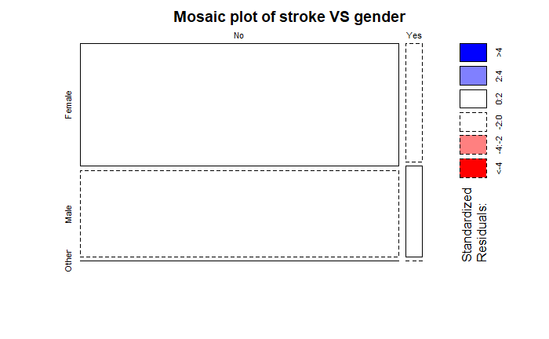

```r
table1<-table(hcdsd$stroke,hcdsd$gender)
mosaicplot(table1, main = "Mosaic plot of stroke VS gender", shade = TRUE)
```

```r
chisq.test(table1)
```

```
    Pearson's Chi-squared test

data:  table1
X-squared = 0.47259, df = 2, p-value = 0.7895
```

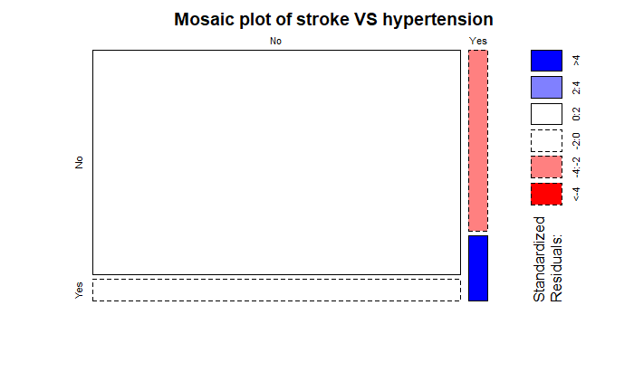

```r
table2<-table(hcdsd$stroke,hcdsd$hypertension)
mosaicplot(table2, main = "Mosaic plot of stroke VS hypertension", shade = TRUE)
```

```r
chisq.test(table2)
```

```
    Pearson's Chi-squared test with Yates' continuity correction

data:  table2
X-squared = 81.605, df = 1, p-value < 2.2e-16
```

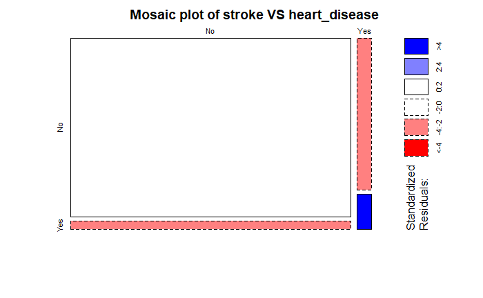

```r
table3<-table(hcdsd$stroke,hcdsd$heart_disease)
mosaicplot(table3, main = "Mosaic plot of stroke VS heart_disease", shade = TRUE)
```

```r
chisq.test(table3)
```

```
    Pearson's Chi-squared test with Yates' continuity correction

data:  table3
X-squared = 90.26, df = 1, p-value < 2.2e-16
```

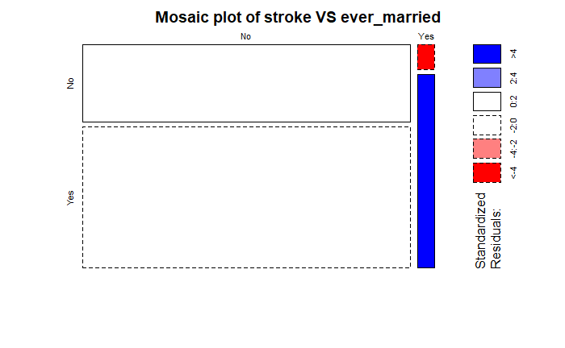

```r
table4<-table(hcdsd$stroke,hcdsd$ever_married)
mosaicplot(table4, main = "Mosaic plot of stroke VS ever_married", shade = TRUE)
```

```r
chisq.test(table4)
```

```
    Pearson's Chi-squared test with Yates' continuity correction

data:  table4
X-squared = 58.924, df = 1, p-value = 1.639e-14
```

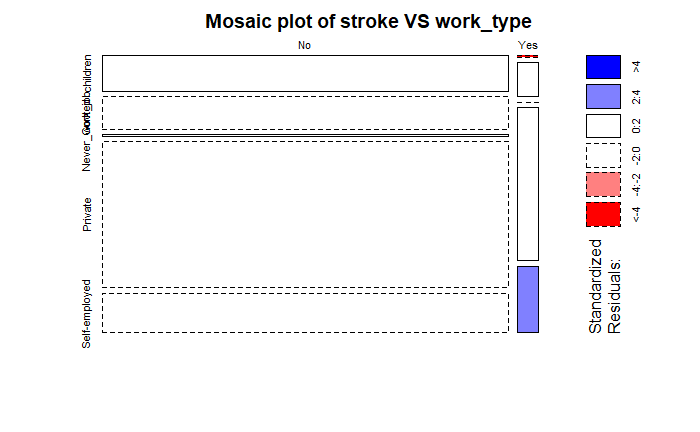

```r
table5<-table(hcdsd$stroke,hcdsd$work_type)
mosaicplot(table5, main = "Mosaic plot of stroke VS work_type", shade = TRUE)
```

```r
chisq.test(table5)
```

```
    Pearson's Chi-squared test

data:  table5
X-squared = 49.164, df = 4, p-value = 5.398e-10
```

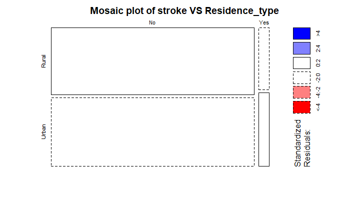

```r
table6<-table(hcdsd$stroke,hcdsd$Residence_type)
mosaicplot(table6, main = "Mosaic plot of stroke VS Residence_type", shade = TRUE)
```

```r
chisq.test(table6)
```

```
    Pearson's Chi-squared test with Yates' continuity correction

data:  table6
X-squared = 1.0816, df = 1, p-value = 0.2983
```

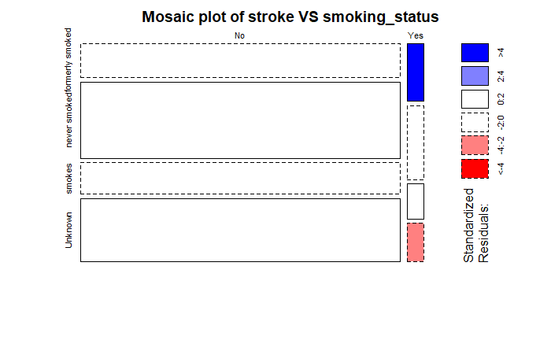

```r
table7<-table(hcdsd$stroke,hcdsd$smoking_status)
mosaicplot(table7, main = "Mosaic plot of stroke VS smoking_status", shade = TRUE)
```

```r
chisq.test(table7)
```

```
    Pearson's Chi-squared test

data:  table7
X-squared = 29.147, df = 3, p-value = 2.085e-06
```

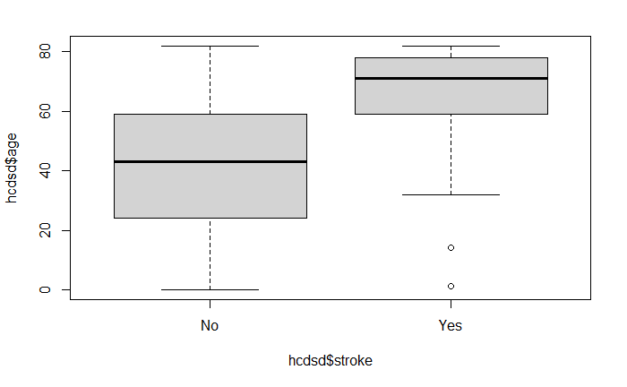

```r
plot(hcdsd$age~hcdsd$stroke)
```

```r
t.test(hcdsd$age~hcdsd$stroke)
```

```
    Welch Two Sample t-test

data:  hcdsd$age by hcdsd$stroke
t = -29.686, df = 331.65, p-value < 2.2e-16
alternative hypothesis: true difference in means between group No and group Yes is not equal to 0
95 percent confidence interval:
 -27.4634 -24.0499
sample estimates:
 mean in group No mean in group Yes
         41.97154          67.72819
```

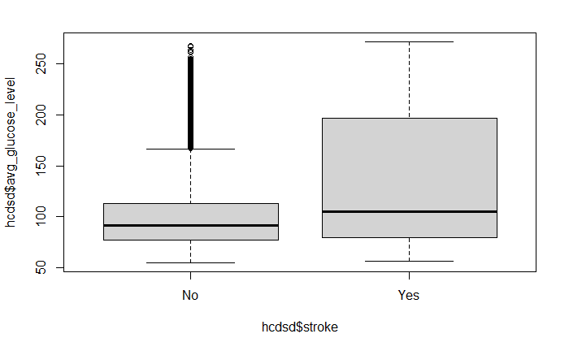

```r
plot(hcdsd$avg_glucose_level~hcdsd$stroke)
```

```r
t.test(hcdsd$avg_glucose_level~hcdsd$stroke)
```

```
    Welch Two Sample t-test

data:  hcdsd$avg_glucose_level by hcdsd$stroke
t = -6.9824, df = 260.89, p-value = 2.401e-11
alternative hypothesis: true difference in means between group No and group Yes is not equal to 0
95 percent confidence interval:
 -35.57474 -19.92371
sample estimates:
 mean in group No mean in group Yes
         104.7955          132.5447
```

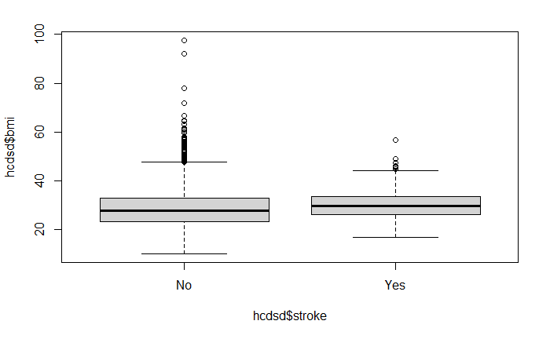

```r
plot(hcdsd$bmi~hcdsd$stroke)
```

```r
t.test(hcdsd$bmi~hcdsd$stroke)
```

```
    Welch Two Sample t-test

data:  hcdsd$bmi by hcdsd$stroke
t = -3.6404, df = 237.83, p-value = 0.000334
alternative hypothesis: true difference in means between group No and group Yes is not equal to 0
95 percent confidence interval:
 -2.5401580 -0.7562981
sample estimates:
 mean in group No mean in group Yes
         28.82306          30.47129
```

ans: variables- hypertension, heart_disease, ever_married, work_type, smoking_status, age, avg_glucose_level, bmi are associated with “stroke” variable

Using caret’s createDataPartition method to partition the dataset to 80% training and 20% testing.

```r
library(caret)
intrain= createDataPartition(hcdsd$stroke, p=0.8, list= FALSE)
hcdsd_train= hcdsd[intrain,]

hcdsd_test = hcdsd[-intrain,]
```

```r
hcdsd_train$bmi[is.na(hcdsd_train$bmi)] <- mean(hcdsd_train$bmi,na.rm=TRUE)
hcdsd_test$bmi[is.na(hcdsd_test$bmi)] <- mean(hcdsd_train$bmi,na.rm=TRUE)
colSums(is.na(hcdsd_train))
```

```
           gender               age      hypertension     heart_disease      ever_married
                0                 0                 0                 0                 0
        work_type    Residence_type avg_glucose_level               bmi    smoking_status
                0                 0                 0                 0                 0
           stroke
                0
```

```r
colSums(is.na(hcdsd_test))
```

```
           gender               age      hypertension     heart_disease      ever_married
                0                 0                 0                 0                 0
        work_type    Residence_type avg_glucose_level               bmi    smoking_status
                0                 0                 0                 0                 0
           stroke
                0
```

```r
str(hcdsd_train)
```

```
'data.frame':   4089 obs. of  11 variables:
 $ gender           : Factor w/ 3 levels "Female","Male",..: 2 2 1 1 2 2 1 1 1 1 ...
 $ age              : num  67 80 49 79 81 74 69 59 78 61 ...
 $ hypertension     : Factor w/ 2 levels "No","Yes": 1 1 1 2 1 2 1 1 1 1 ...
 $ heart_disease    : Factor w/ 2 levels "No","Yes": 2 2 1 1 1 2 1 1 1 2 ...
 $ ever_married     : Factor w/ 2 levels "No","Yes": 2 2 2 2 2 2 1 2 2 2 ...
 $ work_type        : Factor w/ 5 levels "children","Govt_job",..: 4 4 4 5 4 4 4 4 4 2 ...
 $ Residence_type   : Factor w/ 2 levels "Rural","Urban": 2 1 2 1 2 1 2 1 2 1 ...
 $ avg_glucose_level: num  229 106 171 174 186 ...
 $ bmi              : num  36.6 32.5 34.4 24 29 ...
 $ smoking_status   : Factor w/ 4 levels "formerly smoked",..: 1 2 3 2 1 2 2 4 4 3 ...
 $ stroke           : Factor w/ 2 levels "No","Yes": 2 2 2 2 2 2 2 2 2 2 ...
```

```r
str(hcdsd_train$stroke)
```

```
 Factor w/ 2 levels "No","Yes": 2 2 2 2 2 2 2 2 2 2 ...
```

Lasso Linear Regression model

```r
library(caret)
library(RANN)
library(ROCR)
set.seed(1)
lasso <-train(stroke ~ ., data = hcdsd_train, method = "glmnet",verbose=FALSE, metric ="ROC",
trControl= trainControl("cv", number = 10, classProbs= TRUE, summaryFunction= twoClassSummary, sampling="smote"),
tuneGrid= expand.grid(alpha = 1, lambda = 10^seq(-3, 3, length = 100)))
coef(lasso$finalModel, lasso$bestTune$lambda)
```

```
17 x 1 sparse Matrix of class "dgCMatrix"
                                     s1
(Intercept)                -4.307693334
genderMale                  .
genderOther                 .
age                         0.071449528
hypertensionYes             0.598767884
heart_diseaseYes            0.200789881
ever_marriedYes             .
work_typeGovt_job           .
work_typeNever_worked       .
work_typePrivate            .
work_typeSelf-employed     -0.227315114
Residence_typeUrban         .
avg_glucose_level           0.001902376
bmi                         .
smoking_statusnever smoked -0.251190069
smoking_statussmokes        0.023624812
smoking_statusUnknown       .
```

```r
predictions <-predict(lasso,hcdsd_test,na.action = na.pass, type="prob")
lasso_predictions= prediction(predictions$Yes,hcdsd_test$stroke)
lasso_predicted_labels= predict(lasso, hcdsd_test)
confusionMatrix(lasso_predicted_labels, hcdsd_test$stroke, positive="Yes", mode="everything")
```

```
Confusion Matrix and Statistics

          Reference
Prediction  No Yes
       No  709   6
       Yes 263  43

               Accuracy : 0.7365
                 95% CI : (0.7084, 0.7633)
    No Information Rate : 0.952
    P-Value [Acc > NIR] : 1

                  Kappa : 0.1739

 Mcnemar's Test P-Value : <2e-16

            Sensitivity : 0.87755
            Specificity : 0.72942
         Pos Pred Value : 0.14052
         Neg Pred Value : 0.99161
              Precision : 0.14052
                 Recall : 0.87755
                     F1 : 0.24225
             Prevalence : 0.04799
         Detection Rate : 0.04212
   Detection Prevalence : 0.29971
      Balanced Accuracy : 0.80349

       'Positive' Class : Yes
```

```r
performance(lasso_predictions, measure = "auc")@y.values
```

```
[[1]]
[1] 0.8599983
```

Ridge Linear Regression model

```r
set.seed(1)
ridge <-train(stroke ~ ., data = hcdsd_train, method = "glmnet", na.action=na.pass, preProc="knnImpute",verbose=FALSE, metric ="ROC",
trControl= trainControl("cv", number = 10,classProbs= TRUE, summaryFunction= twoClassSummary, sampling="down"),
tuneGrid= expand.grid(alpha = 0, lambda = 10^seq(-3, 3, length = 100)))
predictions1 <-predict(ridge,hcdsd_test,na.action=na.pass, type="prob")
ridge_predictions= prediction(predictions1$Yes,hcdsd_test$stroke)
ridge_predicted_labels= predict(ridge, hcdsd_test)
confusionMatrix(ridge_predicted_labels, hcdsd_test$stroke, positive="Yes", mode="everything")
```

```
Confusion Matrix and Statistics

          Reference
Prediction  No Yes
       No  701   9
       Yes 271  40

               Accuracy : 0.7258
                 95% CI : (0.6973, 0.7529)
    No Information Rate : 0.952
    P-Value [Acc > NIR] : 1

                  Kappa : 0.1519

 Mcnemar's Test P-Value : <2e-16

            Sensitivity : 0.81633
            Specificity : 0.72119
         Pos Pred Value : 0.12862
         Neg Pred Value : 0.98732
              Precision : 0.12862
                 Recall : 0.81633
                     F1 : 0.22222
             Prevalence : 0.04799
         Detection Rate : 0.03918
   Detection Prevalence : 0.30460
      Balanced Accuracy : 0.76876

       'Positive' Class : Yes
```

```r
performance(ridge_predictions, measure = "auc")@y.values
```

```
[[1]]
[1] 0.8320316
```

Elastic-net Linear Regression model

```r
set.seed(1)
enet<-train(stroke ~ ., data = hcdsd_train, method = "glmnet", na.action=na.pass, preProc="knnImpute",verbose=FALSE, metric ="ROC",
trControl= trainControl("cv", number = 10,classProbs= TRUE, summaryFunction= twoClassSummary, sampling="down"),
tuneGrid= expand.grid(alpha =seq(0,1, length=10), lambda = 10^seq(-3, 3, length = 100)))
```

[output not shown]

[output cut: 141 more lines]

[output not shown]

```r
predictions2 <-predict(enet,hcdsd_test,na.action=na.pass, type="prob")
enet_predictions= prediction(predictions2$Yes,hcdsd_test$stroke)
enet_predicted_labels= predict(enet, hcdsd_test)
confusionMatrix(enet_predicted_labels, hcdsd_test$stroke, positive="Yes", mode="everything")
```

```
Confusion Matrix and Statistics

          Reference
Prediction  No Yes
       No  718   8
       Yes 254  41

               Accuracy : 0.7434
                 95% CI : (0.7154, 0.7699)
    No Information Rate : 0.952
    P-Value [Acc > NIR] : 1

                  Kappa : 0.1701

 Mcnemar's Test P-Value : <2e-16

            Sensitivity : 0.83673
            Specificity : 0.73868
         Pos Pred Value : 0.13898
         Neg Pred Value : 0.98898
              Precision : 0.13898
                 Recall : 0.83673
                     F1 : 0.23837
             Prevalence : 0.04799
         Detection Rate : 0.04016
   Detection Prevalence : 0.28893
      Balanced Accuracy : 0.78771

       'Positive' Class : Yes
```

```r
performance(enet_predictions, measure = "auc")@y.values
```

```
[[1]]
[1] 0.8542874
```

Random forest model

```r
set.seed(1)
library(caret)
m_rf<-train(stroke ~ ., data = hcdsd_train,preProc=c("nzv","knnImpute"),importance=T,method = "rf", verbose=FALSE, metric ="ROC", trControl= trainControl(method = "cv", number = 10,classProbs= TRUE, summaryFunction= twoClassSummary, sampling="down"))
m_rf
```

```
Random Forest

4089 samples
  10 predictor
   2 classes: 'No', 'Yes'

Pre-processing: nearest neighbor imputation (14), centered (14), scaled (14), remove (2)
Resampling: Cross-Validated (10 fold)
Summary of sample sizes: 3681, 3680, 3680, 3680, 3680, 3680, ...
Addtional sampling using down-sampling prior to pre-processing

Resampling results across tuning parameters:

  mtry  ROC        Sens       Spec
   2    0.8129592  0.6808907  0.805
   9    0.8284033  0.6932307  0.825
  16    0.8123612  0.6973465  0.780

ROC was used to select the optimal model using the largest value.
The final value used for the model was mtry = 9.
```

```r
predictions3<-predict(m_rf, hcdsd_test, type = "prob")
rf_predictions= prediction(predictions3$Yes,hcdsd_test$stroke)
rf_predicted_labels= predict(m_rf, hcdsd_test)
confusionMatrix(rf_predicted_labels, hcdsd_test$stroke, positive="Yes", mode="everything")
```

```
Confusion Matrix and Statistics

          Reference
Prediction  No Yes
       No  648  14
       Yes 324  35

               Accuracy : 0.669
                 95% CI : (0.6391, 0.6978)
    No Information Rate : 0.952
    P-Value [Acc > NIR] : 1

                  Kappa : 0.0951

 Mcnemar's Test P-Value : <2e-16

            Sensitivity : 0.71429
            Specificity : 0.66667
         Pos Pred Value : 0.09749
         Neg Pred Value : 0.97885
              Precision : 0.09749
                 Recall : 0.71429
                     F1 : 0.17157
             Prevalence : 0.04799
         Detection Rate : 0.03428
   Detection Prevalence : 0.35162
      Balanced Accuracy : 0.69048

       'Positive' Class : Yes
```

```r
performance(rf_predictions, measure = "auc")@y.values
```

```
[[1]]
[1] 0.7792055
```

```r
varImp(m_rf)
```

```
rf variable importance
```

|  | Importance |
| --- | --- |
| age | 100.00000000 |
| bmi | 20.73077092 |
| avg_glucose_level | 19.38897687 |
| smoking_statusnever smoked | 9.72198175 |
| heart_diseaseYes | 8.17595050 |
| ever_marriedYes | 7.50100857 |
| hypertensionYes | 7.10778306 |
| smoking_statussmokes | 3.28191016 |
| genderMale | 3.11568143 |
| smoking_statusUnknown | 2.11403669 |

[output cut: 4 more lines]

```r
t=table(hcdsd_train$stroke)
t
```

```
  No  Yes
3889  200
```

```r
w_yes=sum(t)/(t["Yes"]*2)
w_no=sum(t)/(t["No"]*2)
w_yes
```

```
    Yes
10.2225
```

```r
w_no
```

```
       No
0.5257136
```

```r
class_weights= ifelse(hcdsd_train$stroke=="Yes", w_yes, w_no)
str(class_weights)
```

```
 num [1:4089] 10.2 10.2 10.2 10.2 10.2 ...
```

Gradient Boosted Tree model

```r
library(caret)
library(ROCR)
set.seed(1)
ctrl=trainControl(method="cv", number=10, classProbs= TRUE, summaryFunction= twoClassSummary,sampling="down")
gbm<-train(stroke ~ ., data = hcdsd_train, method = "gbm",preProc="nzv", verbose=FALSE, metric ="ROC", trControl= ctrl)
gbm
```

```
Stochastic Gradient Boosting

4089 samples
  10 predictor
   2 classes: 'No', 'Yes'

Pre-processing: remove (2)
Resampling: Cross-Validated (10 fold)
Summary of sample sizes: 3681, 3680, 3680, 3680, 3680, 3680, ...
Addtional sampling using down-sampling prior to pre-processing

Resampling results across tuning parameters:

  interaction.depth  n.trees  ROC        Sens       Spec
  1                   50      0.8396400  0.6857764  0.855
  1                  100      0.8357714  0.7073768  0.835
  1                  150      0.8333311  0.7042920  0.825
  2                   50      0.8364679  0.7132974  0.855
  2                  100      0.8317944  0.7099548  0.820
  2                  150      0.8292616  0.7125275  0.820
  3                   50      0.8321867  0.7140639  0.815
  3                  100      0.8253725  0.7135525  0.815
  3                  150      0.8232256  0.7076392  0.785

Tuning parameter 'shrinkage' was held constant at a value of 0.1
Tuning parameter 'n.minobsinnode' was held constant at a value of 10
ROC was used to select the optimal model using the largest value.
The final values used for the model were n.trees = 50, interaction.depth = 1, shrinkage = 0.1 and n.minobsinnode = 10.
```

```r
gbm_predictions_prob=predict(gbm, hcdsd_test, type="prob")
gbm_predictions= prediction(gbm_predictions_prob$Yes,hcdsd_test$stroke)
performance(gbm_predictions, measure = "auc")@y.values
```

```
[[1]]
[1] 0.8252394
```

```r
gbm_predicted_labels= predict(gbm, hcdsd_test)
confusionMatrix(gbm_predicted_labels, hcdsd_test$stroke, positive="Yes", mode="everything")
```

```
Confusion Matrix and Statistics

          Reference
Prediction  No Yes
       No  641   6
       Yes 331  43

               Accuracy : 0.6699
                 95% CI : (0.6401, 0.6987)
    No Information Rate : 0.952
    P-Value [Acc > NIR] : 1

                  Kappa : 0.1294

 Mcnemar's Test P-Value : <2e-16

            Sensitivity : 0.87755
            Specificity : 0.65947
         Pos Pred Value : 0.11497
         Neg Pred Value : 0.99073
              Precision : 0.11497
                 Recall : 0.87755
                     F1 : 0.20331
             Prevalence : 0.04799
         Detection Rate : 0.04212
   Detection Prevalence : 0.36631
      Balanced Accuracy : 0.76851

       'Positive' Class : Yes
```

Support vector machine model with method=“svmLinear”

```r
library(caret)
svm<-train(
stroke ~ ., data = hcdsd_train, method = "svmLinear",verbose=FALSE, metric ="ROC",
trControl= trainControl("cv", number = 10, classProbs= TRUE, summaryFunction= twoClassSummary,sampling="down"))
svm
```

```
Support Vector Machines with Linear Kernel

4089 samples
  10 predictor
   2 classes: 'No', 'Yes'

No pre-processing
Resampling: Cross-Validated (10 fold)
Summary of sample sizes: 3680, 3680, 3680, 3680, 3680, 3680, ...
Addtional sampling using down-sampling

Resampling results:

  ROC        Sens       Spec
  0.8447508  0.7253856  0.8

Tuning parameter 'C' was held constant at a value of 1
```

```r
predictions4<-predict(svm,hcdsd_test,type="prob")
svm_predictions= prediction(predictions4$Yes,hcdsd_test$stroke)
svm_predicted_labels= predict(svm, hcdsd_test)
confusionMatrix(svm_predicted_labels, hcdsd_test$stroke, positive="Yes", mode="everything")
```

```
Confusion Matrix and Statistics

          Reference
Prediction  No Yes
       No  713  11
       Yes 259  38

               Accuracy : 0.7356
                 95% CI : (0.7074, 0.7624)
    No Information Rate : 0.952
    P-Value [Acc > NIR] : 1

                  Kappa : 0.1496

 Mcnemar's Test P-Value : <2e-16

            Sensitivity : 0.77551
            Specificity : 0.73354
         Pos Pred Value : 0.12795
         Neg Pred Value : 0.98481
              Precision : 0.12795
                 Recall : 0.77551
                     F1 : 0.21965
             Prevalence : 0.04799
         Detection Rate : 0.03722
   Detection Prevalence : 0.29089
      Balanced Accuracy : 0.75452

       'Positive' Class : Yes
```

```r
performance(svm_predictions, measure = "auc")@y.values
```

```
[[1]]
[1] 0.8309188
```

Support vector machine model with method=“svmRadial”

```r
library(caret)
svm_rad<-train(
stroke ~ ., data = hcdsd_train, method = "svmRadial",verbose=FALSE, metric ="ROC",
trControl= trainControl("cv", number = 10,classProbs= TRUE, summaryFunction= twoClassSummary,sampling="down"))
svm_rad
```

```
Support Vector Machines with Radial Basis Function Kernel

4089 samples
  10 predictor
   2 classes: 'No', 'Yes'

No pre-processing
Resampling: Cross-Validated (10 fold)
Summary of sample sizes: 3680, 3680, 3680, 3680, 3680, 3680, ...
Addtional sampling using down-sampling

Resampling results across tuning parameters:

  C     ROC        Sens       Spec
  0.25  0.7246462  0.7567434  0.520
  0.50  0.7371928  0.7171528  0.645
  1.00  0.7161476  0.7379833  0.620

Tuning parameter 'sigma' was held constant at a value of 0.05168089
ROC was used to select the optimal model using the largest value.
The final values used for the model were sigma = 0.05168089 and C = 0.5.
```

```r
predictions4_rad<-predict(svm_rad,hcdsd_test,type="prob")
svm_rad_predictions= prediction(predictions4_rad$Yes,hcdsd_test$stroke)
svm_rad_predicted_labels= predict(svm_rad, hcdsd_test)
confusionMatrix(svm_rad_predicted_labels, hcdsd_test$stroke, positive="Yes", mode="everything")
```

```
Confusion Matrix and Statistics

          Reference
Prediction  No Yes
       No  735  16
       Yes 237  33

               Accuracy : 0.7522
                 95% CI : (0.7245, 0.7784)
    No Information Rate : 0.952
    P-Value [Acc > NIR] : 1

                  Kappa : 0.1368

 Mcnemar's Test P-Value : <2e-16

            Sensitivity : 0.67347
            Specificity : 0.75617
         Pos Pred Value : 0.12222
         Neg Pred Value : 0.97870
              Precision : 0.12222
                 Recall : 0.67347
                     F1 : 0.20690
             Prevalence : 0.04799
         Detection Rate : 0.03232
   Detection Prevalence : 0.26445
      Balanced Accuracy : 0.71482

       'Positive' Class : Yes
```

```r
performance(svm_rad_predictions, measure = "auc")@y.values
```

```
[[1]]
[1] 0.7737885
```

```r
compare=resamples(list(L=lasso,R=ridge,E=enet,RF=m_rf,G=gbm,S=svm,SR=svm_rad))
summary(compare)
```

[output not shown]

```r
str(hcdsd_train)
```

```
'data.frame':   4089 obs. of  11 variables:
 $ gender           : Factor w/ 3 levels "Female","Male",..: 2 1 2 1 1 1 1 1 2 1 ...
 $ age              : num  67 61 81 69 59 78 81 61 78 50 ...
 $ hypertension     : Factor w/ 2 levels "No","Yes": 1 1 1 1 1 1 2 1 1 2 ...
 $ heart_disease    : Factor w/ 2 levels "No","Yes": 2 1 1 1 1 1 1 2 2 1 ...
 $ ever_married     : Factor w/ 2 levels "No","Yes": 2 2 2 1 2 2 2 2 2 2 ...
 $ work_type        : Factor w/ 5 levels "children","Govt_job",..: 4 5 4 4 4 4 4 2 4 5 ...
 $ Residence_type   : Factor w/ 2 levels "Rural","Urban": 2 1 2 2 1 2 1 1 2 1 ...
 $ avg_glucose_level: num  228.7 202.2 186.2 94.4 76.2 ...
 $ bmi              : num  36.6 28.9 29 22.8 28.9 ...
 $ smoking_status   : Factor w/ 4 levels "formerly smoked",..: 1 2 1 2 4 4 2 3 4 2 ...
 $ stroke           : Factor w/ 2 levels "No","Yes": 2 2 2 2 2 2 2 2 2 2 ...
```

```r
str(hcdsd_test)
```

```
'data.frame':   1021 obs. of  11 variables:
 $ gender           : Factor w/ 3 levels "Female","Male",..: 2 1 1 2 1 1 2 1 1 2 ...
 $ age              : num  80 49 79 74 54 79 64 79 39 78 ...
 $ hypertension     : Factor w/ 2 levels "No","Yes": 1 1 2 2 1 1 1 1 2 2 ...
 $ heart_disease    : Factor w/ 2 levels "No","Yes": 2 1 1 2 1 2 2 1 1 1 ...
 $ ever_married     : Factor w/ 2 levels "No","Yes": 2 2 2 2 2 2 2 2 2 2 ...
 $ work_type        : Factor w/ 5 levels "children","Govt_job",..: 4 4 5 4 4 4 4 5 4 4 ...
 $ Residence_type   : Factor w/ 2 levels "Rural","Urban": 1 2 1 1 2 2 2 2 1 2 ...
 $ avg_glucose_level: num  105.9 171.2 174.1 70.1 104.5 ...
 $ bmi              : num  32.5 34.4 24 27.4 27.3 ...
 $ smoking_status   : Factor w/ 4 levels "formerly smoked",..: 2 3 2 2 3 2 3 2 3 1 ...
 $ stroke           : Factor w/ 2 levels "No","Yes": 2 2 2 2 2 2 2 2 2 2 ...
```

Neural networks require a numeric target variable. In case of a binary classification, the target variable must be coded as 0 and 1. so, converting stroke into numeric.

```r
#hcdsd_train$stroke=as.integer(hcdsd_train$stroke)
hcdsd_train$stroke=as.numeric(hcdsd_train$stroke)-1
hcdsd_train$hypertension=as.numeric(hcdsd_train$hypertension)
hcdsd_train$heart_disease=as.numeric(hcdsd_train$heart_disease)

hcdsd_test$stroke=as.numeric(hcdsd_test$stroke)-1
hcdsd_test$hypertension=as.numeric(hcdsd_test$hypertension)
hcdsd_test$heart_disease=as.numeric(hcdsd_test$heart_disease)
```

The categorical variables ever_married, Residence_type have only two levels so we just convert it to a binary vector

```r
hcdsd_train$ever_married=ifelse(hcdsd_train$ever_married=="No",0,1)
hcdsd_train$Residence_type=ifelse(hcdsd_train$Residence_type=="Rural",0,1)

hcdsd_test$ever_married=ifelse(hcdsd_test$ever_married=="No",0,1)
hcdsd_test$Residence_type=ifelse(hcdsd_test$Residence_type=="Rural",0,1)
```

The rest of the categorical variables (gender, work_type,smoking_status) don’t have a natural ordering so we one-hot-encode them.

```r
library(mltools)
library(data.table)
hcdsd_train= data.frame(one_hot(as.data.table(hcdsd_train),dropUnusedLevels = FALSE))
hcdsd_test= data.frame(one_hot(as.data.table(hcdsd_test),dropUnusedLevels = FALSE))
```

```r
str(hcdsd_train)
```

```
'data.frame':   4089 obs. of  20 variables:
 $ gender_Female                 : int  0 1 0 1 0 0 1 1 1 1 ...
 $ gender_Male                   : int  1 0 1 0 1 1 0 0 0 0 ...
 $ gender_Other                  : int  0 0 0 0 0 0 0 0 0 0 ...
 $ age                           : num  67 61 80 79 81 74 69 59 78 81 ...
 $ hypertension                  : num  1 1 1 2 1 2 1 1 1 2 ...
 $ heart_disease                 : num  2 1 2 1 1 2 1 1 1 1 ...
 $ ever_married                  : num  1 1 1 1 1 1 0 1 1 1 ...
 $ work_type_children            : int  0 0 0 0 0 0 0 0 0 0 ...
 $ work_type_Govt_job            : int  0 0 0 0 0 0 0 0 0 0 ...
 $ work_type_Never_worked        : int  0 0 0 0 0 0 0 0 0 0 ...
 $ work_type_Private             : int  1 0 1 0 1 1 1 1 1 1 ...
 $ work_type_Self.employed       : int  0 1 0 1 0 0 0 0 0 0 ...
 $ Residence_type                : num  1 0 0 0 1 0 1 0 1 0 ...
 $ avg_glucose_level             : num  229 202 106 174 186 ...
 $ bmi                           : num  36.6 28.9 32.5 24 29 ...
 $ smoking_status_formerly.smoked: int  1 0 0 0 1 0 0 0 0 0 ...
 $ smoking_status_never.smoked   : int  0 1 1 1 0 1 1 0 0 1 ...
 $ smoking_status_smokes         : int  0 0 0 0 0 0 0 0 0 0 ...
 $ smoking_status_Unknown        : int  0 0 0 0 0 0 0 1 1 0 ...
 $ stroke                        : num  1 1 1 1 1 1 1 1 1 1 ...
```

```r
str(hcdsd_test)
```

```
'data.frame':   1021 obs. of  20 variables:
 $ gender_Female                 : int  1 1 1 1 0 0 0 0 0 1 ...
 $ gender_Male                   : int  0 0 0 0 1 1 1 1 1 0 ...
 $ gender_Other                  : int  0 0 0 0 0 0 0 0 0 0 ...
 $ age                           : num  49 60 71 52 80 58 57 54 60 79 ...
 $ hypertension                  : num  1 1 1 2 1 1 2 1 2 1 ...
 $ heart_disease                 : num  1 1 1 1 1 1 1 1 1 2 ...
 $ ever_married                  : num  1 0 1 1 1 1 1 1 1 1 ...
 $ work_type_children            : int  0 0 0 0 0 0 0 0 0 0 ...
 $ work_type_Govt_job            : int  0 0 1 0 0 0 0 0 1 0 ...
 $ work_type_Never_worked        : int  0 0 0 0 0 0 0 0 0 0 ...
 $ work_type_Private             : int  1 1 0 0 0 1 1 1 0 1 ...
 $ work_type_Self.employed       : int  0 0 0 1 1 0 0 0 0 0 ...
 $ Residence_type                : num  1 1 0 1 0 0 1 1 1 0 ...
 $ avg_glucose_level             : num  171.2 89.2 193.9 233.3 104.1 ...
 $ bmi                           : num  34.4 37.8 22.4 48.9 23.5 ...
 $ smoking_status_formerly.smoked: int  0 0 0 0 0 0 0 0 0 0 ...
 $ smoking_status_never.smoked   : int  0 1 0 1 1 0 0 1 0 1 ...
 $ smoking_status_smokes         : int  1 0 1 0 0 0 1 0 1 0 ...
 $ smoking_status_Unknown        : int  0 0 0 0 0 1 0 0 0 0 ...
 $ stroke                        : num  1 1 1 1 1 1 1 1 1 1 ...
```

```r
hcdsd_train
```

| gender_Female | gender_Male | gender_Other | age | hypertension | heart_disease | ever_married | work_type_children | work_type_Govt_job | work_type_Never_worked | work_type_Private | work_type_Self.employed | Residence_type | avg_glucose_level | bmi | smoking_status_formerly.smoked | smoking_status_never.smoked | smoking_status_smokes | smoking_status_Unknown | stroke |
| --- | --- | --- | --- | --- | --- | --- | --- | --- | --- | --- | --- | --- | --- | --- | --- | --- | --- | --- | --- |
| 0 | 1 | 0 | 67.00 | 1 | 2 | 1 | 0 | 0 | 0 | 1 | 0 | 1 | 228.69 | 36.60000 | 1 | 0 | 0 | 0 | 1 |
| 1 | 0 | 0 | 61.00 | 1 | 1 | 1 | 0 | 0 | 0 | 0 | 1 | 0 | 202.21 | 28.88627 | 0 | 1 | 0 | 0 | 1 |
| 0 | 1 | 0 | 80.00 | 1 | 2 | 1 | 0 | 0 | 0 | 1 | 0 | 0 | 105.92 | 32.50000 | 0 | 1 | 0 | 0 | 1 |
| 1 | 0 | 0 | 79.00 | 2 | 1 | 1 | 0 | 0 | 0 | 0 | 1 | 0 | 174.12 | 24.00000 | 0 | 1 | 0 | 0 | 1 |
| 0 | 1 | 0 | 81.00 | 1 | 1 | 1 | 0 | 0 | 0 | 1 | 0 | 1 | 186.21 | 29.00000 | 1 | 0 | 0 | 0 | 1 |
| 0 | 1 | 0 | 74.00 | 2 | 2 | 1 | 0 | 0 | 0 | 1 | 0 | 0 | 70.09 | 27.40000 | 0 | 1 | 0 | 0 | 1 |
| 1 | 0 | 0 | 69.00 | 1 | 1 | 0 | 0 | 0 | 0 | 1 | 0 | 1 | 94.39 | 22.80000 | 0 | 1 | 0 | 0 | 1 |
| 1 | 0 | 0 | 59.00 | 1 | 1 | 1 | 0 | 0 | 0 | 1 | 0 | 0 | 76.15 | 28.88627 | 0 | 0 | 0 | 1 | 1 |
| 1 | 0 | 0 | 78.00 | 1 | 1 | 1 | 0 | 0 | 0 | 1 | 0 | 1 | 58.57 | 24.20000 | 0 | 0 | 0 | 1 | 1 |
| 1 | 0 | 0 | 81.00 | 2 | 1 | 1 | 0 | 0 | 0 | 1 | 0 | 0 | 80.43 | 29.70000 | 0 | 1 | 0 | 0 | 1 |

[output cut: 990 more lines]

```r
numeric_cols=c("age","avg_glucose_level","bmi")
col_means_train<-attr(scale(hcdsd_train[,numeric_cols]), "scaled:center")
col_stddevs_train<-attr( scale(hcdsd_train[,numeric_cols]), "scaled:scale")
```

down sampling for neural networks

```r
hcdsd_train1= hcdsd_train[hcdsd_train$stroke==0,]
hcdsd_train1
```

|  | gender_Female | gender_Male | gender_Other | age | hypertension | heart_disease | ever_married | work_type_children | work_type_Govt_job | work_type_Never_worked | work_type_Private | work_type_Self.employed | Residence_type | avg_glucose_level | bmi | smoking_status_formerly.smoked | smoking_status_never.smoked | smoking_status_smokes | smoking_status_Unknown | stroke |
| --- | --- | --- | --- | --- | --- | --- | --- | --- | --- | --- | --- | --- | --- | --- | --- | --- | --- | --- | --- | --- |
| 201 | 0 | 1 | 0 | 3.00 | 1 | 1 | 0 | 1 | 0 | 0 | 0 | 0 | 0 | 95.12 | 18.00000 | 0 | 0 | 0 | 1 | 0 |
| 202 | 1 | 0 | 0 | 8.00 | 1 | 1 | 0 | 0 | 0 | 0 | 1 | 0 | 1 | 110.89 | 17.60000 | 0 | 0 | 0 | 1 | 0 |
| 203 | 1 | 0 | 0 | 70.00 | 1 | 1 | 1 | 0 | 0 | 0 | 1 | 0 | 0 | 69.04 | 35.90000 | 1 | 0 | 0 | 0 | 0 |
| 204 | 1 | 0 | 0 | 52.00 | 1 | 1 | 1 | 0 | 0 | 0 | 1 | 0 | 1 | 77.59 | 17.70000 | 1 | 0 | 0 | 0 | 0 |
| 205 | 1 | 0 | 0 | 32.00 | 1 | 1 | 1 | 0 | 0 | 0 | 1 | 0 | 0 | 77.67 | 32.30000 | 0 | 0 | 1 | 0 | 0 |
| 206 | 1 | 0 | 0 | 79.00 | 1 | 1 | 1 | 0 | 1 | 0 | 0 | 0 | 1 | 77.08 | 35.00000 | 0 | 0 | 0 | 1 | 0 |
| 207 | 0 | 1 | 0 | 79.00 | 1 | 2 | 1 | 0 | 0 | 0 | 1 | 0 | 1 | 57.08 | 22.00000 | 1 | 0 | 0 | 0 | 0 |
| 208 | 1 | 0 | 0 | 37.00 | 1 | 1 | 1 | 0 | 0 | 0 | 1 | 0 | 0 | 73.50 | 26.10000 | 1 | 0 | 0 | 0 | 0 |
| 209 | 1 | 0 | 0 | 40.00 | 1 | 1 | 1 | 0 | 0 | 0 | 1 | 0 | 0 | 95.04 | 42.40000 | 0 | 1 | 0 | 0 | 0 |
| 210 | 0 | 1 | 0 | 35.00 | 1 | 1 | 0 | 0 | 0 | 0 | 1 | 0 | 0 | 85.37 | 33.00000 | 0 | 1 | 0 | 0 | 0 |

[output cut: 990 more lines]

```r
hcdsd_train2= hcdsd_train[hcdsd_train$stroke==1,]
hcdsd_train2
```

[output not shown]

[output cut: 190 more lines]

```r
train_sample<-sample(3889, 200)
hcdsd_train3<-hcdsd_train1[train_sample,]
hcdsd_train3
```

|  | gender_Female | gender_Male | gender_Other | age | hypertension | heart_disease | ever_married | work_type_children | work_type_Govt_job | work_type_Never_worked | work_type_Private | work_type_Self.employed | Residence_type | avg_glucose_level | bmi | smoking_status_formerly.smoked | smoking_status_never.smoked | smoking_status_smokes | smoking_status_Unknown | stroke |
| --- | --- | --- | --- | --- | --- | --- | --- | --- | --- | --- | --- | --- | --- | --- | --- | --- | --- | --- | --- | --- |
| 3070 | 0 | 1 | 0 | 6.00 | 1 | 1 | 0 | 1 | 0 | 0 | 0 | 0 | 1 | 90.60 | 16.60000 | 0 | 0 | 0 | 1 | 0 |
| 3161 | 0 | 1 | 0 | 36.00 | 1 | 1 | 0 | 0 | 0 | 0 | 1 | 0 | 1 | 200.68 | 25.80000 | 0 | 0 | 0 | 1 | 0 |
| 2178 | 1 | 0 | 0 | 46.00 | 1 | 1 | 0 | 0 | 1 | 0 | 0 | 0 | 0 | 112.29 | 23.50000 | 0 | 0 | 0 | 1 | 0 |
| 3730 | 0 | 1 | 0 | 2.00 | 1 | 1 | 0 | 1 | 0 | 0 | 0 | 0 | 0 | 96.47 | 19.50000 | 0 | 0 | 0 | 1 | 0 |
| 934 | 1 | 0 | 0 | 52.00 | 2 | 1 | 0 | 0 | 0 | 0 | 1 | 0 | 1 | 73.00 | 25.20000 | 0 | 0 | 1 | 0 | 0 |
| 2271 | 0 | 1 | 0 | 20.00 | 1 | 1 | 0 | 0 | 0 | 0 | 1 | 0 | 0 | 88.47 | 28.10000 | 0 | 0 | 1 | 0 | 0 |
| 1230 | 0 | 1 | 0 | 71.00 | 1 | 1 | 1 | 0 | 0 | 0 | 1 | 0 | 1 | 108.43 | 32.80000 | 0 | 0 | 1 | 0 | 0 |
| 2638 | 1 | 0 | 0 | 5.00 | 1 | 1 | 0 | 1 | 0 | 0 | 0 | 0 | 0 | 73.92 | 17.20000 | 0 | 0 | 0 | 1 | 0 |
| 3984 | 1 | 0 | 0 | 63.00 | 1 | 1 | 1 | 0 | 0 | 0 | 1 | 0 | 1 | 57.06 | 37.90000 | 0 | 1 | 0 | 0 | 0 |
| 3471 | 0 | 1 | 0 | 4.00 | 1 | 1 | 0 | 1 | 0 | 0 | 0 | 0 | 1 | 80.48 | 17.70000 | 0 | 0 | 0 | 1 | 0 |

[output cut: 190 more lines]

```r
hcdsd_train4<-rbind(hcdsd_train3, hcdsd_train2)
hcdsd_train4
```

|  | gender_Female | gender_Male | gender_Other | age | hypertension | heart_disease | ever_married | work_type_children | work_type_Govt_job | work_type_Never_worked | work_type_Private | work_type_Self.employed | Residence_type | avg_glucose_level | bmi | smoking_status_formerly.smoked | smoking_status_never.smoked | smoking_status_smokes | smoking_status_Unknown | stroke |
| --- | --- | --- | --- | --- | --- | --- | --- | --- | --- | --- | --- | --- | --- | --- | --- | --- | --- | --- | --- | --- |
| 3070 | 0 | 1 | 0 | 6.00 | 1 | 1 | 0 | 1 | 0 | 0 | 0 | 0 | 1 | 90.60 | 16.60000 | 0 | 0 | 0 | 1 | 0 |
| 3161 | 0 | 1 | 0 | 36.00 | 1 | 1 | 0 | 0 | 0 | 0 | 1 | 0 | 1 | 200.68 | 25.80000 | 0 | 0 | 0 | 1 | 0 |
| 2178 | 1 | 0 | 0 | 46.00 | 1 | 1 | 0 | 0 | 1 | 0 | 0 | 0 | 0 | 112.29 | 23.50000 | 0 | 0 | 0 | 1 | 0 |
| 3730 | 0 | 1 | 0 | 2.00 | 1 | 1 | 0 | 1 | 0 | 0 | 0 | 0 | 0 | 96.47 | 19.50000 | 0 | 0 | 0 | 1 | 0 |
| 934 | 1 | 0 | 0 | 52.00 | 2 | 1 | 0 | 0 | 0 | 0 | 1 | 0 | 1 | 73.00 | 25.20000 | 0 | 0 | 1 | 0 | 0 |
| 2271 | 0 | 1 | 0 | 20.00 | 1 | 1 | 0 | 0 | 0 | 0 | 1 | 0 | 0 | 88.47 | 28.10000 | 0 | 0 | 1 | 0 | 0 |
| 1230 | 0 | 1 | 0 | 71.00 | 1 | 1 | 1 | 0 | 0 | 0 | 1 | 0 | 1 | 108.43 | 32.80000 | 0 | 0 | 1 | 0 | 0 |
| 2638 | 1 | 0 | 0 | 5.00 | 1 | 1 | 0 | 1 | 0 | 0 | 0 | 0 | 0 | 73.92 | 17.20000 | 0 | 0 | 0 | 1 | 0 |
| 3984 | 1 | 0 | 0 | 63.00 | 1 | 1 | 1 | 0 | 0 | 0 | 1 | 0 | 1 | 57.06 | 37.90000 | 0 | 1 | 0 | 0 | 0 |
| 3471 | 0 | 1 | 0 | 4.00 | 1 | 1 | 0 | 1 | 0 | 0 | 0 | 0 | 1 | 80.48 | 17.70000 | 0 | 0 | 0 | 1 | 0 |

[output cut: 390 more lines]

```r
library(caret)
intrain1= createDataPartition(hcdsd_train$stroke, p=0.9, list= FALSE)
hcdsd_train_x= hcdsd_train[intrain1, -20]
hcdsd_train_y= hcdsd_train[intrain1, 20]

hcdsd_val_x= hcdsd_train[-intrain1, -20]
hcdsd_val_y= hcdsd_train[-intrain1, 20]
```

```r
numeric_cols=c("age","avg_glucose_level","bmi")
col_means_train1<-attr(scale(hcdsd_train4[,numeric_cols]), "scaled:center")
col_stddevs_train1<-attr( scale(hcdsd_train4[,numeric_cols]), "scaled:scale")
```

```r
hcdsd_train_x[numeric_cols]= scale(hcdsd_train_x[numeric_cols])
hcdsd_val_x[numeric_cols]= scale(hcdsd_val_x[numeric_cols], center = col_means_train, scale = col_stddevs_train)
hcdsd_test[numeric_cols]<-scale(hcdsd_test[numeric_cols], center = col_means_train, scale = col_stddevs_train)
```

```r
str(hcdsd_train_x)
```

```
'data.frame':   3681 obs. of  19 variables:
 $ gender_Female                 : int  0 1 0 1 1 0 0 1 1 1 ...
 $ gender_Male                   : int  1 0 1 0 0 1 1 0 0 0 ...
 $ gender_Other                  : int  0 0 0 0 0 0 0 0 0 0 ...
 $ age                           : num  1.048 0.783 1.622 0.252 1.578 ...
 $ hypertension                  : num  1 1 1 1 2 1 2 1 1 1 ...
 $ heart_disease                 : num  2 1 2 1 1 1 2 1 1 1 ...
 $ ever_married                  : num  1 1 1 1 1 1 1 0 1 1 ...
 $ work_type_children            : int  0 0 0 0 0 0 0 0 0 0 ...
 $ work_type_Govt_job            : int  0 0 0 0 0 0 0 0 0 0 ...
 $ work_type_Never_worked        : int  0 0 0 0 0 0 0 0 0 0 ...
 $ work_type_Private             : int  1 0 1 1 0 1 1 1 1 1 ...
 $ work_type_Self.employed       : int  0 1 0 0 1 0 0 0 0 0 ...
 $ Residence_type                : num  1 0 0 1 0 1 0 1 0 1 ...
 $ avg_glucose_level             : num  2.69725 2.11343 -0.00956 1.43038 1.4941 ...
 $ bmi                           : num  0.98471 -0.00297 0.46013 0.70323 -0.6274 ...
 $ smoking_status_formerly.smoked: int  1 0 0 0 0 1 0 0 0 0 ...
 $ smoking_status_never.smoked   : int  0 1 1 0 1 0 1 1 0 0 ...
 $ smoking_status_smokes         : int  0 0 0 1 0 0 0 0 0 0 ...
 $ smoking_status_Unknown        : int  0 0 0 0 0 0 0 0 1 1 ...
```

```r
library(keras)
model <-keras_model_sequential() %>%
layer_dense(units = 32, activation = "relu",
input_shape= dim(hcdsd_train_x)[2]) %>%
layer_dense(units = 32,activation="relu" )%>%
layer_dense(units = 1, activation="sigmoid")
model %>% compile(
loss = "binary_crossentropy",
optimizer = "adam" , metrics="AUC")
model %>% fit(as.matrix(hcdsd_train_x),hcdsd_train_y,batch_size=50,epochs = 20,verbose=2, validation_data=list(as.matrix(hcdsd_val_x),hcdsd_val_y),class_weight=list("0"=w_no, "1"=w_yes))
```

```
74/74 - 2s - loss: 0.6476 - auc: 0.7131 - val_loss: 0.6515 - val_auc: 0.8106 - 2s/epoch - 23ms/step
74/74 - 0s - loss: 0.5476 - auc: 0.8137 - val_loss: 0.5310 - val_auc: 0.8025 - 362ms/epoch - 5ms/step
74/74 - 0s - loss: 0.5026 - auc: 0.8370 - val_loss: 0.5871 - val_auc: 0.8033 - 397ms/epoch - 5ms/step
74/74 - 0s - loss: 0.4870 - auc: 0.8458 - val_loss: 0.4886 - val_auc: 0.8024 - 332ms/epoch - 4ms/step
74/74 - 0s - loss: 0.4760 - auc: 0.8508 - val_loss: 0.5029 - val_auc: 0.8040 - 348ms/epoch - 5ms/step
74/74 - 0s - loss: 0.4669 - auc: 0.8571 - val_loss: 0.4664 - val_auc: 0.7992 - 377ms/epoch - 5ms/step
74/74 - 0s - loss: 0.4643 - auc: 0.8583 - val_loss: 0.5219 - val_auc: 0.8017 - 330ms/epoch - 4ms/step
74/74 - 0s - loss: 0.4589 - auc: 0.8619 - val_loss: 0.4488 - val_auc: 0.7950 - 334ms/epoch - 5ms/step
74/74 - 0s - loss: 0.4551 - auc: 0.8640 - val_loss: 0.5454 - val_auc: 0.7974 - 347ms/epoch - 5ms/step
74/74 - 0s - loss: 0.4505 - auc: 0.8664 - val_loss: 0.5283 - val_auc: 0.7962 - 333ms/epoch - 5ms/step
74/74 - 0s - loss: 0.4444 - auc: 0.8709 - val_loss: 0.3823 - val_auc: 0.7922 - 331ms/epoch - 4ms/step
74/74 - 0s - loss: 0.4466 - auc: 0.8694 - val_loss: 0.5510 - val_auc: 0.7928 - 345ms/epoch - 5ms/step
74/74 - 0s - loss: 0.4399 - auc: 0.8729 - val_loss: 0.4757 - val_auc: 0.7944 - 333ms/epoch - 5ms/step
74/74 - 0s - loss: 0.4375 - auc: 0.8738 - val_loss: 0.5278 - val_auc: 0.7937 - 347ms/epoch - 5ms/step
74/74 - 0s - loss: 0.4365 - auc: 0.8738 - val_loss: 0.5102 - val_auc: 0.7917 - 341ms/epoch - 5ms/step
74/74 - 0s - loss: 0.4329 - auc: 0.8754 - val_loss: 0.4269 - val_auc: 0.7864 - 332ms/epoch - 4ms/step
74/74 - 0s - loss: 0.4309 - auc: 0.8766 - val_loss: 0.4747 - val_auc: 0.7886 - 349ms/epoch - 5ms/step
74/74 - 0s - loss: 0.4272 - auc: 0.8792 - val_loss: 0.5339 - val_auc: 0.7900 - 333ms/epoch - 5ms/step
74/74 - 0s - loss: 0.4220 - auc: 0.8820 - val_loss: 0.4674 - val_auc: 0.7855 - 345ms/epoch - 5ms/step
74/74 - 0s - loss: 0.4200 - auc: 0.8831 - val_loss: 0.5326 - val_auc: 0.7922 - 333ms/epoch - 5ms/step
```

```r
str(hcdsd_train_x)
```

```
'data.frame':   3681 obs. of  19 variables:
 $ gender_Female                 : int  0 1 0 1 1 1 1 1 0 1 ...
 $ gender_Male                   : int  1 0 1 0 0 0 0 0 1 0 ...
 $ gender_Other                  : int  0 0 0 0 0 0 0 0 0 0 ...
 $ age                           : num  1.051 0.784 1.674 1.14 0.696 ...
 $ hypertension                  : num  1 1 1 1 1 1 2 1 1 2 ...
 $ heart_disease                 : num  2 1 1 1 1 1 1 2 2 1 ...
 $ ever_married                  : num  1 1 1 0 1 1 1 1 1 1 ...
 $ work_type_children            : int  0 0 0 0 0 0 0 0 0 0 ...
 $ work_type_Govt_job            : int  0 0 0 0 0 0 0 1 0 0 ...
 $ work_type_Never_worked        : int  0 0 0 0 0 0 0 0 0 0 ...
 $ work_type_Private             : int  1 0 1 1 1 1 1 0 1 0 ...
 $ work_type_Self.employed       : int  0 1 0 0 0 0 0 0 0 1 ...
 $ Residence_type                : num  1 0 1 1 0 1 0 0 1 0 ...
 $ avg_glucose_level             : num  2.701 2.117 1.765 -0.26 -0.662 ...
 $ bmi                           : num  0.99858 -0.00277 0.00898 -0.79834 -0.00277 ...
 $ smoking_status_formerly.smoked: int  1 0 1 0 0 0 0 0 0 0 ...
 $ smoking_status_never.smoked   : int  0 1 0 1 0 0 1 0 0 1 ...
 $ smoking_status_smokes         : int  0 0 0 0 0 0 0 1 0 0 ...
 $ smoking_status_Unknown        : int  0 0 0 0 1 1 0 0 1 0 ...
```

```r
str(hcdsd_test)
```

```
'data.frame':   1021 obs. of  20 variables:
 $ gender_Female                 : int  1 1 1 1 0 0 0 0 0 1 ...
 $ gender_Male                   : int  0 0 0 0 1 1 1 1 1 0 ...
 $ gender_Other                  : int  0 0 0 0 0 0 0 0 0 0 ...
 $ age                           : num  0.26 0.747 1.235 0.393 1.634 ...
 $ hypertension                  : num  1 1 1 2 1 1 2 1 2 1 ...
 $ heart_disease                 : num  1 1 1 1 1 1 1 1 1 2 ...
 $ ever_married                  : num  1 0 1 1 1 1 1 1 1 1 ...
 $ work_type_children            : int  0 0 0 0 0 0 0 0 0 0 ...
 $ work_type_Govt_job            : int  0 0 1 0 0 0 0 0 1 0 ...
 $ work_type_Never_worked        : int  0 0 0 0 0 0 0 0 0 0 ...
 $ work_type_Private             : int  1 1 0 0 0 1 1 1 0 1 ...
 $ work_type_Self.employed       : int  0 0 0 1 1 0 0 0 0 0 ...
 $ Residence_type                : num  1 1 0 1 0 0 1 1 1 0 ...
 $ avg_glucose_level             : num  1.4502 -0.3726 1.9549 2.8296 -0.0414 ...
 $ bmi                           : num  0.714 1.155 -0.84 2.592 -0.698 ...
 $ smoking_status_formerly.smoked: int  0 0 0 0 0 0 0 0 0 0 ...
 $ smoking_status_never.smoked   : int  0 1 0 1 1 0 0 1 0 1 ...
 $ smoking_status_smokes         : int  1 0 1 0 0 0 1 0 1 0 ...
 $ smoking_status_Unknown        : int  0 0 0 0 0 1 0 0 0 0 ...
 $ stroke                        : num  1 1 1 1 1 1 1 1 1 1 ...
```

```r
predicted_probs= model%>% predict(as.matrix(hcdsd_test[,-20]))
ann_predictions= prediction(predicted_probs,hcdsd_test[,20])
performance(ann_predictions, measure = "auc")@y.values
```

```
[[1]]
[1] 0.7919921
```

```r
predicted.labels= factor(ifelse(predicted_probs>0.5, "1", "0"))
confusionMatrix(predicted.labels, as.factor(hcdsd_test[,20]), mode="everything", positive="1")
```

```
Confusion Matrix and Statistics

          Reference
Prediction   0   1
         0 684  11
         1 288  38

               Accuracy : 0.7071
                 95% CI : (0.6782, 0.7349)
    No Information Rate : 0.952
    P-Value [Acc > NIR] : 1

                  Kappa : 0.1301

 Mcnemar's Test P-Value : <2e-16

            Sensitivity : 0.77551
            Specificity : 0.70370
         Pos Pred Value : 0.11656
         Neg Pred Value : 0.98417
              Precision : 0.11656
                 Recall : 0.77551
                     F1 : 0.20267
             Prevalence : 0.04799
         Detection Rate : 0.03722
   Detection Prevalence : 0.31929
      Balanced Accuracy : 0.73961

       'Positive' Class : 1
```

```r
library(tfruns)
 runs=tuning_run("hcdsd_hyperparameters.R",
            flags = list(
              learning_rate = c(0.1, 0.01, 0.001, 0.0001),
              batch_size = c(32,32,1),
              activation_function = c("relu","sigmoid","tanh"),
              units1= c(16,32,64,128),
              units2= c(16,32,64,128)
            ),
            sample = 0.01
 )
```

```
576 total combinations of flags
(sampled to 6 combinations)
```

```r
Y
```

```
Training run 1/6 (flags = list(0.001, 32, "sigmoid", 32, 128))
Using run directory runs/2022-05-04T04-06-28Z
```

```
> FLAGS= flags(
+   flag_numeric("learning_rate", 0.01),
+   flag_numeric("units1", 32),
+   flag_numeric("units2", 32),
+   flag_numeric("batch_size ..." ... [TRUNCATED]

> library(keras)

> model <- keras_model_sequential() %>%
+   layer_dense(units=FLAGS$units1, input_shape=dim(hcdsd_train_x)[2], activation=FLAGS$activation_function) % .... [TRUNCATED]

> model %>% compile( loss="binary_crossentropy",
+                    optimizer=optimizer_adam(learning_rate=FLAGS$learning_rate), metric="AUC" )

> model %>% fit (as.matrix(hcdsd_train_x), hcdsd_train_y, epochs=20,
+                batch_size=FLAGS$batch_size,
+                validation_data= .... [TRUNCATED]
```

```
WARNING:tensorflow:Callback method `on_train_batch_end` is slow compared to the batch time (batch time: 0.0014s vs `on_train_batch_end` time: 0.0045s). Check your callbacks.
```

```
116/116 - 2s - loss: 0.6873 - auc: 0.6022 - val_loss: 0.5503 - val_auc: 0.8076 - 2s/epoch - 17ms/step
116/116 - 0s - loss: 0.6321 - auc: 0.7701 - val_loss: 0.7635 - val_auc: 0.8067 - 441ms/epoch - 4ms/step
116/116 - 0s - loss: 0.5698 - auc: 0.8187 - val_loss: 0.5298 - val_auc: 0.8095 - 474ms/epoch - 4ms/step
116/116 - 0s - loss: 0.5266 - auc: 0.8298 - val_loss: 0.5671 - val_auc: 0.8089 - 431ms/epoch - 4ms/step
116/116 - 0s - loss: 0.5045 - auc: 0.8361 - val_loss: 0.5592 - val_auc: 0.8047 - 442ms/epoch - 4ms/step
116/116 - 0s - loss: 0.4989 - auc: 0.8381 - val_loss: 0.4105 - val_auc: 0.8034 - 445ms/epoch - 4ms/step
116/116 - 0s - loss: 0.4906 - auc: 0.8417 - val_loss: 0.4947 - val_auc: 0.8049 - 446ms/epoch - 4ms/step
116/116 - 0s - loss: 0.4921 - auc: 0.8400 - val_loss: 0.3937 - val_auc: 0.8053 - 426ms/epoch - 4ms/step
116/116 - 0s - loss: 0.4985 - auc: 0.8346 - val_loss: 0.5438 - val_auc: 0.8074 - 460ms/epoch - 4ms/step
116/116 - 0s - loss: 0.4872 - auc: 0.8444 - val_loss: 0.4982 - val_auc: 0.8095 - 443ms/epoch - 4ms/step
116/116 - 0s - loss: 0.4848 - auc: 0.8460 - val_loss: 0.5908 - val_auc: 0.8087 - 463ms/epoch - 4ms/step
116/116 - 0s - loss: 0.4925 - auc: 0.8412 - val_loss: 0.5066 - val_auc: 0.8063 - 473ms/epoch - 4ms/step
116/116 - 0s - loss: 0.4853 - auc: 0.8451 - val_loss: 0.4501 - val_auc: 0.8057 - 446ms/epoch - 4ms/step
116/116 - 0s - loss: 0.4831 - auc: 0.8450 - val_loss: 0.4910 - val_auc: 0.8074 - 443ms/epoch - 4ms/step
116/116 - 0s - loss: 0.4826 - auc: 0.8478 - val_loss: 0.4652 - val_auc: 0.8072 - 444ms/epoch - 4ms/step
116/116 - 0s - loss: 0.4862 - auc: 0.8452 - val_loss: 0.5345 - val_auc: 0.8086 - 478ms/epoch - 4ms/step
116/116 - 0s - loss: 0.4840 - auc: 0.8452 - val_loss: 0.5003 - val_auc: 0.8090 - 443ms/epoch - 4ms/step
116/116 - 0s - loss: 0.4832 - auc: 0.8444 - val_loss: 0.4411 - val_auc: 0.8092 - 461ms/epoch - 4ms/step
116/116 - 0s - loss: 0.4877 - auc: 0.8428 - val_loss: 0.5324 - val_auc: 0.8099 - 442ms/epoch - 4ms/step
116/116 - 0s - loss: 0.4851 - auc: 0.8470 - val_loss: 0.5370 - val_auc: 0.8089 - 463ms/epoch - 4ms/step
```

```
Run completed: runs/2022-05-04T04-06-28Z

Training run 2/6 (flags = list(1e-04, 1, "tanh", 16, 128))
Using run directory runs/2022-05-04T04-09-22Z
```

```
> FLAGS= flags(
+   flag_numeric("learning_rate", 0.01),
+   flag_numeric("units1", 32),
+   flag_numeric("units2", 32),
+   flag_numeric("batch_size ..." ... [TRUNCATED]

> library(keras)

> model <- keras_model_sequential() %>%
+   layer_dense(units=FLAGS$units1, input_shape=dim(hcdsd_train_x)[2], activation=FLAGS$activation_function) % .... [TRUNCATED]

> model %>% compile( loss="binary_crossentropy",
+                    optimizer=optimizer_adam(learning_rate=FLAGS$learning_rate), metric="AUC" )

> model %>% fit (as.matrix(hcdsd_train_x), hcdsd_train_y, epochs=20,
+                batch_size=FLAGS$batch_size,
+                validation_data= .... [TRUNCATED]
```

```
WARNING:tensorflow:Callback method `on_train_batch_end` is slow compared to the batch time (batch time: 0.0012s vs `on_train_batch_end` time: 0.0039s). Check your callbacks.
```

```
3681/3681 - 9s - loss: 0.5569 - auc: 0.8050 - val_loss: 0.4988 - val_auc: 0.7704 - 9s/epoch - 2ms/step
3681/3681 - 8s - loss: 0.5093 - auc: 0.8290 - val_loss: 0.5034 - val_auc: 0.7731 - 8s/epoch - 2ms/step
3681/3681 - 8s - loss: 0.5003 - auc: 0.8335 - val_loss: 0.5129 - val_auc: 0.7761 - 8s/epoch - 2ms/step
3681/3681 - 8s - loss: 0.4966 - auc: 0.8368 - val_loss: 0.5401 - val_auc: 0.7811 - 8s/epoch - 2ms/step
3681/3681 - 8s - loss: 0.4944 - auc: 0.8384 - val_loss: 0.5342 - val_auc: 0.7840 - 8s/epoch - 2ms/step
3681/3681 - 8s - loss: 0.4926 - auc: 0.8402 - val_loss: 0.5279 - val_auc: 0.7894 - 8s/epoch - 2ms/step
3681/3681 - 8s - loss: 0.4896 - auc: 0.8423 - val_loss: 0.5362 - val_auc: 0.7909 - 8s/epoch - 2ms/step
3681/3681 - 8s - loss: 0.4883 - auc: 0.8433 - val_loss: 0.5104 - val_auc: 0.7948 - 8s/epoch - 2ms/step
3681/3681 - 9s - loss: 0.4863 - auc: 0.8439 - val_loss: 0.5354 - val_auc: 0.8008 - 9s/epoch - 2ms/step
3681/3681 - 8s - loss: 0.4849 - auc: 0.8461 - val_loss: 0.5286 - val_auc: 0.7977 - 8s/epoch - 2ms/step
3681/3681 - 8s - loss: 0.4831 - auc: 0.8482 - val_loss: 0.4823 - val_auc: 0.7977 - 8s/epoch - 2ms/step
3681/3681 - 8s - loss: 0.4835 - auc: 0.8468 - val_loss: 0.5134 - val_auc: 0.7977 - 8s/epoch - 2ms/step
3681/3681 - 8s - loss: 0.4811 - auc: 0.8480 - val_loss: 0.5160 - val_auc: 0.8001 - 8s/epoch - 2ms/step
3681/3681 - 8s - loss: 0.4798 - auc: 0.8490 - val_loss: 0.5336 - val_auc: 0.8027 - 8s/epoch - 2ms/step
3681/3681 - 8s - loss: 0.4770 - auc: 0.8512 - val_loss: 0.5678 - val_auc: 0.8056 - 8s/epoch - 2ms/step
3681/3681 - 8s - loss: 0.4749 - auc: 0.8520 - val_loss: 0.4558 - val_auc: 0.7980 - 8s/epoch - 2ms/step
3681/3681 - 8s - loss: 0.4774 - auc: 0.8498 - val_loss: 0.5201 - val_auc: 0.8019 - 8s/epoch - 2ms/step
3681/3681 - 8s - loss: 0.4773 - auc: 0.8517 - val_loss: 0.5023 - val_auc: 0.8021 - 8s/epoch - 2ms/step
3681/3681 - 8s - loss: 0.4754 - auc: 0.8513 - val_loss: 0.5522 - val_auc: 0.8018 - 8s/epoch - 2ms/step
3681/3681 - 8s - loss: 0.4741 - auc: 0.8528 - val_loss: 0.4539 - val_auc: 0.7972 - 8s/epoch - 2ms/step
```

```
Run completed: runs/2022-05-04T04-09-22Z

Training run 3/6 (flags = list(0.1, 32, "relu", 128, 64))
Using run directory runs/2022-05-04T04-13-36Z
```

```
> FLAGS= flags(
+   flag_numeric("learning_rate", 0.01),
+   flag_numeric("units1", 32),
+   flag_numeric("units2", 32),
+   flag_numeric("batch_size ..." ... [TRUNCATED]

> library(keras)

> model <- keras_model_sequential() %>%
+   layer_dense(units=FLAGS$units1, input_shape=dim(hcdsd_train_x)[2], activation=FLAGS$activation_function) % .... [TRUNCATED]

> model %>% compile( loss="binary_crossentropy",
+                    optimizer=optimizer_adam(learning_rate=FLAGS$learning_rate), metric="AUC" )

> model %>% fit (as.matrix(hcdsd_train_x), hcdsd_train_y, epochs=20,
+                batch_size=FLAGS$batch_size,
+                validation_data= .... [TRUNCATED]
```

```
WARNING:tensorflow:Callback method `on_train_batch_end` is slow compared to the batch time (batch time: 0.0012s vs `on_train_batch_end` time: 0.0063s). Check your callbacks.
```

```
116/116 - 2s - loss: 0.9283 - auc: 0.6993 - val_loss: 1.7494 - val_auc: 0.4028 - 2s/epoch - 15ms/step
116/116 - 0s - loss: 0.6545 - auc: 0.7126 - val_loss: 0.4562 - val_auc: 0.6851 - 452ms/epoch - 4ms/step
116/116 - 0s - loss: 0.6033 - auc: 0.7378 - val_loss: 0.3716 - val_auc: 0.6721 - 461ms/epoch - 4ms/step
116/116 - 0s - loss: 0.6570 - auc: 0.7451 - val_loss: 0.8764 - val_auc: 0.4722 - 443ms/epoch - 4ms/step
116/116 - 0s - loss: 0.6684 - auc: 0.6626 - val_loss: 0.6484 - val_auc: 0.5895 - 493ms/epoch - 4ms/step
116/116 - 0s - loss: 0.7790 - auc: 0.6248 - val_loss: 0.6073 - val_auc: 0.5448 - 449ms/epoch - 4ms/step
116/116 - 0s - loss: 0.7061 - auc: 0.5138 - val_loss: 0.7147 - val_auc: 0.5038 - 440ms/epoch - 4ms/step
116/116 - 0s - loss: 0.7368 - auc: 0.5039 - val_loss: 0.8350 - val_auc: 0.5026 - 444ms/epoch - 4ms/step
116/116 - 0s - loss: 0.7024 - auc: 0.4766 - val_loss: 0.6881 - val_auc: 0.4987 - 473ms/epoch - 4ms/step
116/116 - 0s - loss: 0.6999 - auc: 0.5150 - val_loss: 0.7117 - val_auc: 0.5013 - 444ms/epoch - 4ms/step
116/116 - 0s - loss: 0.7024 - auc: 0.4803 - val_loss: 0.6807 - val_auc: 0.5013 - 445ms/epoch - 4ms/step
116/116 - 0s - loss: 0.6942 - auc: 0.5036 - val_loss: 0.5683 - val_auc: 0.5864 - 445ms/epoch - 4ms/step
116/116 - 0s - loss: 1.0021 - auc: 0.5060 - val_loss: 0.6568 - val_auc: 0.5000 - 461ms/epoch - 4ms/step
116/116 - 0s - loss: 0.7042 - auc: 0.4907 - val_loss: 0.8000 - val_auc: 0.5000 - 445ms/epoch - 4ms/step
116/116 - 0s - loss: 0.7256 - auc: 0.4811 - val_loss: 0.6542 - val_auc: 0.5000 - 448ms/epoch - 4ms/step
116/116 - 0s - loss: 0.6985 - auc: 0.5220 - val_loss: 0.5192 - val_auc: 0.5000 - 459ms/epoch - 4ms/step
116/116 - 0s - loss: 0.7093 - auc: 0.4730 - val_loss: 0.7628 - val_auc: 0.5000 - 442ms/epoch - 4ms/step
116/116 - 0s - loss: 0.7013 - auc: 0.4861 - val_loss: 0.6207 - val_auc: 0.5000 - 444ms/epoch - 4ms/step
116/116 - 0s - loss: 0.7015 - auc: 0.4699 - val_loss: 0.7441 - val_auc: 0.5000 - 443ms/epoch - 4ms/step
116/116 - 0s - loss: 0.7041 - auc: 0.4726 - val_loss: 0.7609 - val_auc: 0.5000 - 473ms/epoch - 4ms/step
```

```
Run completed: runs/2022-05-04T04-13-36Z

Training run 4/6 (flags = list(1e-04, 32, "relu", 32, 64))
Using run directory runs/2022-05-04T04-14-04Z
```

```
> FLAGS= flags(
+   flag_numeric("learning_rate", 0.01),
+   flag_numeric("units1", 32),
+   flag_numeric("units2", 32),
+   flag_numeric("batch_size ..." ... [TRUNCATED]

> library(keras)

> model <- keras_model_sequential() %>%
+   layer_dense(units=FLAGS$units1, input_shape=dim(hcdsd_train_x)[2], activation=FLAGS$activation_function) % .... [TRUNCATED]

> model %>% compile( loss="binary_crossentropy",
+                    optimizer=optimizer_adam(learning_rate=FLAGS$learning_rate), metric="AUC" )

> model %>% fit (as.matrix(hcdsd_train_x), hcdsd_train_y, epochs=20,
+                batch_size=FLAGS$batch_size,
+                validation_data= .... [TRUNCATED]
```

```
WARNING:tensorflow:Callback method `on_train_batch_end` is slow compared to the batch time (batch time: 0.0014s vs `on_train_batch_end` time: 0.0043s). Check your callbacks.
```

```
116/116 - 2s - loss: 0.7044 - auc: 0.5565 - val_loss: 0.5879 - val_auc: 0.5642 - 2s/epoch - 15ms/step
116/116 - 0s - loss: 0.6660 - auc: 0.6640 - val_loss: 0.5857 - val_auc: 0.6634 - 423ms/epoch - 4ms/step
116/116 - 0s - loss: 0.6336 - auc: 0.7377 - val_loss: 0.5778 - val_auc: 0.7165 - 430ms/epoch - 4ms/step
116/116 - 0s - loss: 0.6043 - auc: 0.7803 - val_loss: 0.5625 - val_auc: 0.7554 - 447ms/epoch - 4ms/step
116/116 - 0s - loss: 0.5783 - auc: 0.8084 - val_loss: 0.5523 - val_auc: 0.7713 - 456ms/epoch - 4ms/step
116/116 - 0s - loss: 0.5554 - auc: 0.8235 - val_loss: 0.5324 - val_auc: 0.7829 - 425ms/epoch - 4ms/step
116/116 - 0s - loss: 0.5373 - auc: 0.8313 - val_loss: 0.5259 - val_auc: 0.7865 - 447ms/epoch - 4ms/step
116/116 - 0s - loss: 0.5233 - auc: 0.8369 - val_loss: 0.5212 - val_auc: 0.7919 - 444ms/epoch - 4ms/step
116/116 - 0s - loss: 0.5121 - auc: 0.8400 - val_loss: 0.5245 - val_auc: 0.7974 - 444ms/epoch - 4ms/step
116/116 - 0s - loss: 0.5039 - auc: 0.8424 - val_loss: 0.5224 - val_auc: 0.7992 - 427ms/epoch - 4ms/step
116/116 - 0s - loss: 0.4975 - auc: 0.8443 - val_loss: 0.5160 - val_auc: 0.8007 - 445ms/epoch - 4ms/step
116/116 - 0s - loss: 0.4923 - auc: 0.8460 - val_loss: 0.5300 - val_auc: 0.8044 - 441ms/epoch - 4ms/step
116/116 - 0s - loss: 0.4883 - auc: 0.8475 - val_loss: 0.5217 - val_auc: 0.8027 - 450ms/epoch - 4ms/step
116/116 - 1s - loss: 0.4852 - auc: 0.8482 - val_loss: 0.5046 - val_auc: 0.8028 - 519ms/epoch - 4ms/step
116/116 - 0s - loss: 0.4831 - auc: 0.8489 - val_loss: 0.5008 - val_auc: 0.8024 - 430ms/epoch - 4ms/step
116/116 - 0s - loss: 0.4817 - auc: 0.8492 - val_loss: 0.5017 - val_auc: 0.8041 - 460ms/epoch - 4ms/step
116/116 - 0s - loss: 0.4793 - auc: 0.8504 - val_loss: 0.5018 - val_auc: 0.8050 - 432ms/epoch - 4ms/step
116/116 - 0s - loss: 0.4777 - auc: 0.8513 - val_loss: 0.5055 - val_auc: 0.8065 - 447ms/epoch - 4ms/step
116/116 - 0s - loss: 0.4758 - auc: 0.8523 - val_loss: 0.4944 - val_auc: 0.8062 - 410ms/epoch - 4ms/step
116/116 - 0s - loss: 0.4746 - auc: 0.8526 - val_loss: 0.4987 - val_auc: 0.8066 - 445ms/epoch - 4ms/step
```

```
Run completed: runs/2022-05-04T04-14-04Z

Training run 5/6 (flags = list(0.01, 32, "tanh", 64, 128))
Using run directory runs/2022-05-04T04-14-31Z
```

```
> FLAGS= flags(
+   flag_numeric("learning_rate", 0.01),
+   flag_numeric("units1", 32),
+   flag_numeric("units2", 32),
+   flag_numeric("batch_size ..." ... [TRUNCATED]

> library(keras)

> model <- keras_model_sequential() %>%
+   layer_dense(units=FLAGS$units1, input_shape=dim(hcdsd_train_x)[2], activation=FLAGS$activation_function) % .... [TRUNCATED]

> model %>% compile( loss="binary_crossentropy",
+                    optimizer=optimizer_adam(learning_rate=FLAGS$learning_rate), metric="AUC" )

> model %>% fit (as.matrix(hcdsd_train_x), hcdsd_train_y, epochs=20,
+                batch_size=FLAGS$batch_size,
+                validation_data= .... [TRUNCATED]
```

```
WARNING:tensorflow:Callback method `on_train_batch_end` is slow compared to the batch time (batch time: 0.0012s vs `on_train_batch_end` time: 0.0041s). Check your callbacks.
```

```
116/116 - 2s - loss: 0.6025 - auc: 0.7765 - val_loss: 0.6129 - val_auc: 0.7832 - 2s/epoch - 15ms/step
116/116 - 0s - loss: 0.5157 - auc: 0.8265 - val_loss: 0.6421 - val_auc: 0.7828 - 442ms/epoch - 4ms/step
116/116 - 0s - loss: 0.5343 - auc: 0.8163 - val_loss: 0.3353 - val_auc: 0.7819 - 443ms/epoch - 4ms/step
116/116 - 0s - loss: 0.5208 - auc: 0.8221 - val_loss: 0.5767 - val_auc: 0.8133 - 446ms/epoch - 4ms/step
116/116 - 0s - loss: 0.5230 - auc: 0.8180 - val_loss: 0.7964 - val_auc: 0.8098 - 456ms/epoch - 4ms/step
116/116 - 0s - loss: 0.5148 - auc: 0.8263 - val_loss: 0.5493 - val_auc: 0.7927 - 445ms/epoch - 4ms/step
116/116 - 0s - loss: 0.5193 - auc: 0.8251 - val_loss: 0.5416 - val_auc: 0.7859 - 476ms/epoch - 4ms/step
116/116 - 0s - loss: 0.5197 - auc: 0.8234 - val_loss: 0.4985 - val_auc: 0.7801 - 445ms/epoch - 4ms/step
116/116 - 0s - loss: 0.5010 - auc: 0.8377 - val_loss: 0.5197 - val_auc: 0.4603 - 491ms/epoch - 4ms/step
116/116 - 0s - loss: 0.5158 - auc: 0.8303 - val_loss: 0.4480 - val_auc: 0.7875 - 442ms/epoch - 4ms/step
116/116 - 0s - loss: 0.5362 - auc: 0.8181 - val_loss: 0.8207 - val_auc: 0.8040 - 461ms/epoch - 4ms/step
116/116 - 0s - loss: 0.5028 - auc: 0.8359 - val_loss: 0.3690 - val_auc: 0.7656 - 428ms/epoch - 4ms/step
116/116 - 0s - loss: 0.5263 - auc: 0.8182 - val_loss: 0.4405 - val_auc: 0.8036 - 456ms/epoch - 4ms/step
116/116 - 0s - loss: 0.4943 - auc: 0.8415 - val_loss: 0.6468 - val_auc: 0.7898 - 443ms/epoch - 4ms/step
116/116 - 0s - loss: 0.5268 - auc: 0.8276 - val_loss: 0.8751 - val_auc: 0.7594 - 464ms/epoch - 4ms/step
116/116 - 0s - loss: 0.5039 - auc: 0.8345 - val_loss: 0.6448 - val_auc: 0.8095 - 456ms/epoch - 4ms/step
116/116 - 0s - loss: 0.4882 - auc: 0.8432 - val_loss: 0.8385 - val_auc: 0.7919 - 445ms/epoch - 4ms/step
116/116 - 0s - loss: 0.4914 - auc: 0.8398 - val_loss: 0.3689 - val_auc: 0.7164 - 458ms/epoch - 4ms/step
116/116 - 0s - loss: 0.4686 - auc: 0.8536 - val_loss: 0.4704 - val_auc: 0.7618 - 443ms/epoch - 4ms/step
116/116 - 0s - loss: 0.4666 - auc: 0.8586 - val_loss: 0.5907 - val_auc: 0.7496 - 444ms/epoch - 4ms/step
```

```
Run completed: runs/2022-05-04T04-14-31Z

Training run 6/6 (flags = list(1e-04, 32, "relu", 128, 128))
Using run directory runs/2022-05-04T04-14-59Z
```

```
> FLAGS= flags(
+   flag_numeric("learning_rate", 0.01),
+   flag_numeric("units1", 32),
+   flag_numeric("units2", 32),
+   flag_numeric("batch_size ..." ... [TRUNCATED]

> library(keras)

> model <- keras_model_sequential() %>%
+   layer_dense(units=FLAGS$units1, input_shape=dim(hcdsd_train_x)[2], activation=FLAGS$activation_function) % .... [TRUNCATED]

> model %>% compile( loss="binary_crossentropy",
+                    optimizer=optimizer_adam(learning_rate=FLAGS$learning_rate), metric="AUC" )

> model %>% fit (as.matrix(hcdsd_train_x), hcdsd_train_y, epochs=20,
+                batch_size=FLAGS$batch_size,
+                validation_data= .... [TRUNCATED]
```

```
WARNING:tensorflow:Callback method `on_train_batch_end` is slow compared to the batch time (batch time: 0.0020s vs `on_train_batch_end` time: 0.0045s). Check your callbacks.
```

```
116/116 - 2s - loss: 0.6391 - auc: 0.7676 - val_loss: 0.6265 - val_auc: 0.7540 - 2s/epoch - 15ms/step
116/116 - 0s - loss: 0.5652 - auc: 0.8292 - val_loss: 0.5762 - val_auc: 0.7809 - 457ms/epoch - 4ms/step
116/116 - 0s - loss: 0.5237 - auc: 0.8383 - val_loss: 0.5569 - val_auc: 0.7870 - 460ms/epoch - 4ms/step
116/116 - 0s - loss: 0.5023 - auc: 0.8437 - val_loss: 0.5355 - val_auc: 0.7888 - 463ms/epoch - 4ms/step
116/116 - 1s - loss: 0.4892 - auc: 0.8484 - val_loss: 0.5139 - val_auc: 0.7891 - 519ms/epoch - 4ms/step
116/116 - 0s - loss: 0.4813 - auc: 0.8520 - val_loss: 0.5270 - val_auc: 0.7909 - 462ms/epoch - 4ms/step
116/116 - 0s - loss: 0.4765 - auc: 0.8530 - val_loss: 0.5097 - val_auc: 0.7911 - 460ms/epoch - 4ms/step
116/116 - 0s - loss: 0.4714 - auc: 0.8564 - val_loss: 0.4866 - val_auc: 0.7930 - 444ms/epoch - 4ms/step
116/116 - 0s - loss: 0.4682 - auc: 0.8583 - val_loss: 0.4944 - val_auc: 0.7940 - 461ms/epoch - 4ms/step
116/116 - 0s - loss: 0.4643 - auc: 0.8604 - val_loss: 0.4982 - val_auc: 0.7925 - 445ms/epoch - 4ms/step
116/116 - 0s - loss: 0.4615 - auc: 0.8618 - val_loss: 0.4933 - val_auc: 0.7939 - 474ms/epoch - 4ms/step
116/116 - 0s - loss: 0.4604 - auc: 0.8625 - val_loss: 0.5012 - val_auc: 0.7943 - 459ms/epoch - 4ms/step
116/116 - 0s - loss: 0.4571 - auc: 0.8646 - val_loss: 0.4914 - val_auc: 0.7931 - 478ms/epoch - 4ms/step
116/116 - 0s - loss: 0.4545 - auc: 0.8660 - val_loss: 0.5085 - val_auc: 0.7943 - 459ms/epoch - 4ms/step
116/116 - 0s - loss: 0.4512 - auc: 0.8677 - val_loss: 0.5394 - val_auc: 0.7949 - 477ms/epoch - 4ms/step
116/116 - 0s - loss: 0.4490 - auc: 0.8691 - val_loss: 0.4909 - val_auc: 0.7923 - 458ms/epoch - 4ms/step
116/116 - 0s - loss: 0.4472 - auc: 0.8698 - val_loss: 0.5045 - val_auc: 0.7940 - 476ms/epoch - 4ms/step
116/116 - 0s - loss: 0.4443 - auc: 0.8721 - val_loss: 0.5244 - val_auc: 0.7948 - 461ms/epoch - 4ms/step
116/116 - 0s - loss: 0.4435 - auc: 0.8720 - val_loss: 0.5210 - val_auc: 0.7937 - 465ms/epoch - 4ms/step
116/116 - 0s - loss: 0.4406 - auc: 0.8735 - val_loss: 0.4716 - val_auc: 0.7887 - 456ms/epoch - 4ms/step
```

```
Run completed: runs/2022-05-04T04-14-59Z
```

```r
runs=runs[order(runs$metric_val_auc, decreasing=TRUE),]
runs
```

```
Data frame: 6 x 25
```

|  | run_dir | metric_loss | metric_auc | metric_val_loss | metric_val_auc |
| --- | --- | --- | --- | --- | --- |
| 6 | runs/2022-05-04T04-06-28Z | 0.4851 | 0.8470 | 0.5370 | 0.8089 |
| 3 | runs/2022-05-04T04-14-04Z | 0.4746 | 0.8526 | 0.4987 | 0.8066 |
| 5 | runs/2022-05-04T04-09-22Z | 0.4741 | 0.8528 | 0.4539 | 0.7972 |
| 1 | runs/2022-05-04T04-14-59Z | 0.4406 | 0.8735 | 0.4716 | 0.7887 |
| 2 | runs/2022-05-04T04-14-31Z | 0.4666 | 0.8586 | 0.5907 | 0.7496 |
| 4 | runs/2022-05-04T04-13-36Z | 0.7041 | 0.4726 | 0.7609 | 0.5000 |

```
# ... with 20 more columns:
#   flag_learning_rate, flag_units1, flag_units2, flag_batch_size,
#   flag_activation_function, epochs, epochs_completed, metrics, model, loss_function,
#   optimizer, learning_rate, script, start, end, completed, output, source_code, context,
#   type
```

```r
view_run(runs$run_dir[4])
```

```r
hcdsd_train_new=rbind(hcdsd_train_x,hcdsd_val_x)
hcdsd_train_newlabels=c(hcdsd_train_y,hcdsd_val_y)
```

```r
model <-keras_model_sequential() %>%
layer_dense(units = 128, activation = "relu",
input_shape= dim(hcdsd_train_new)[2]) %>%
layer_dense(units = 128,activation="relu" )%>%
layer_dense(units = 1, activation="sigmoid")
model %>% compile(
loss = "binary_crossentropy",
optimizer = optimizer_adam(learning_rate=0.0001) , metrics="AUC")
model %>% fit(as.matrix(hcdsd_train_new),hcdsd_train_newlabels,batch_size=32,epochs = 20,verbose=2, validation_data=list(as.matrix(hcdsd_val_x),hcdsd_val_y),class_weight=list("0"=w_no, "1"=w_yes))
```

```
128/128 - 2s - loss: 0.6242 - auc: 0.7808 - val_loss: 0.5994 - val_auc: 0.7454 - 2s/epoch - 16ms/step
128/128 - 1s - loss: 0.5510 - auc: 0.8237 - val_loss: 0.5802 - val_auc: 0.7691 - 538ms/epoch - 4ms/step
128/128 - 1s - loss: 0.5170 - auc: 0.8314 - val_loss: 0.5299 - val_auc: 0.7849 - 505ms/epoch - 4ms/step
128/128 - 0s - loss: 0.4981 - auc: 0.8409 - val_loss: 0.5388 - val_auc: 0.7989 - 494ms/epoch - 4ms/step
128/128 - 0s - loss: 0.4869 - auc: 0.8458 - val_loss: 0.5020 - val_auc: 0.8062 - 476ms/epoch - 4ms/step
128/128 - 0s - loss: 0.4798 - auc: 0.8488 - val_loss: 0.5024 - val_auc: 0.8110 - 492ms/epoch - 4ms/step
128/128 - 0s - loss: 0.4735 - auc: 0.8525 - val_loss: 0.4864 - val_auc: 0.8141 - 489ms/epoch - 4ms/step
128/128 - 0s - loss: 0.4699 - auc: 0.8541 - val_loss: 0.4918 - val_auc: 0.8167 - 477ms/epoch - 4ms/step
128/128 - 0s - loss: 0.4659 - auc: 0.8561 - val_loss: 0.5014 - val_auc: 0.8223 - 474ms/epoch - 4ms/step
128/128 - 0s - loss: 0.4628 - auc: 0.8574 - val_loss: 0.5211 - val_auc: 0.8267 - 478ms/epoch - 4ms/step
128/128 - 1s - loss: 0.4601 - auc: 0.8592 - val_loss: 0.4973 - val_auc: 0.8271 - 537ms/epoch - 4ms/step
128/128 - 0s - loss: 0.4572 - auc: 0.8607 - val_loss: 0.5054 - val_auc: 0.8314 - 477ms/epoch - 4ms/step
128/128 - 0s - loss: 0.4555 - auc: 0.8619 - val_loss: 0.5017 - val_auc: 0.8344 - 491ms/epoch - 4ms/step
128/128 - 0s - loss: 0.4535 - auc: 0.8632 - val_loss: 0.4634 - val_auc: 0.8323 - 494ms/epoch - 4ms/step
128/128 - 0s - loss: 0.4515 - auc: 0.8637 - val_loss: 0.4856 - val_auc: 0.8345 - 473ms/epoch - 4ms/step
128/128 - 0s - loss: 0.4492 - auc: 0.8654 - val_loss: 0.4905 - val_auc: 0.8366 - 462ms/epoch - 4ms/step
128/128 - 0s - loss: 0.4473 - auc: 0.8660 - val_loss: 0.4842 - val_auc: 0.8362 - 475ms/epoch - 4ms/step
128/128 - 0s - loss: 0.4456 - auc: 0.8672 - val_loss: 0.4888 - val_auc: 0.8370 - 460ms/epoch - 4ms/step
128/128 - 0s - loss: 0.4437 - auc: 0.8686 - val_loss: 0.4691 - val_auc: 0.8395 - 476ms/epoch - 4ms/step
128/128 - 0s - loss: 0.4412 - auc: 0.8702 - val_loss: 0.4930 - val_auc: 0.8426 - 460ms/epoch - 4ms/step
```

```r
summary(model)
```

[output not shown]

```r
str(hcdsd_train_new)
```

```
'data.frame':   4089 obs. of  19 variables:
 $ gender_Female                 : int  1 1 1 1 1 1 1 0 1 1 ...
 $ gender_Male                   : int  0 0 0 0 0 0 0 1 0 0 ...
 $ gender_Other                  : int  0 0 0 0 0 0 0 0 0 0 ...
 $ age                           : num  0.779 1.578 0.691 1.534 1.667 ...
 $ hypertension                  : num  1 2 1 1 2 1 1 1 1 2 ...
 $ heart_disease                 : num  1 1 1 1 1 2 1 2 2 1 ...
 $ ever_married                  : num  1 1 1 1 1 1 1 1 1 1 ...
 $ work_type_children            : int  0 0 0 0 0 0 0 0 0 0 ...
 $ work_type_Govt_job            : int  0 0 0 0 0 1 0 0 0 0 ...
 $ work_type_Never_worked        : int  0 0 0 0 0 0 0 0 0 0 ...
 $ work_type_Private             : int  0 0 1 1 1 0 1 1 1 0 ...
 $ work_type_Self.employed       : int  1 1 0 0 0 0 0 0 0 1 ...
 $ Residence_type                : num  0 0 0 1 0 0 1 1 1 0 ...
 $ avg_glucose_level             : num  2.156 1.532 -0.647 -1.038 -0.552 ...
 $ bmi                           : num  0.00572 -0.64567 0.00572 -0.61975 0.09298 ...
 $ smoking_status_formerly.smoked: int  0 0 0 0 0 0 0 0 0 0 ...
 $ smoking_status_never.smoked   : int  1 1 0 0 1 0 0 0 1 1 ...
 $ smoking_status_smokes         : int  0 0 0 0 0 1 1 0 0 0 ...
 $ smoking_status_Unknown        : int  0 0 1 1 0 0 0 1 0 0 ...
```

```r
str(hcdsd_test)
```

```
'data.frame':   1021 obs. of  20 variables:
 $ gender_Female                 : int  0 1 0 0 1 0 1 0 1 0 ...
 $ gender_Male                   : int  1 0 1 1 0 1 0 1 0 1 ...
 $ gender_Other                  : int  0 0 0 0 0 0 0 0 0 0 ...
 $ age                           : num  1.627 0.249 1.671 1.36 1.138 ...
 $ hypertension                  : num  1 1 1 2 1 2 1 1 1 1 ...
 $ heart_disease                 : num  2 1 1 2 1 1 1 2 1 1 ...
 $ ever_married                  : num  1 1 1 1 0 1 0 0 1 1 ...
 $ work_type_children            : int  0 0 0 0 0 0 0 0 0 0 ...
 $ work_type_Govt_job            : int  0 0 0 0 0 0 0 1 1 0 ...
 $ work_type_Never_worked        : int  0 0 0 0 0 0 0 0 0 0 ...
 $ work_type_Private             : int  1 1 1 1 1 1 1 0 0 1 ...
 $ work_type_Self.employed       : int  0 0 0 0 0 0 0 0 0 0 ...
 $ Residence_type                : num  0 1 1 0 1 1 1 1 0 0 ...
 $ avg_glucose_level             : num  0.00712 1.44986 1.78078 -0.78439 -0.24759 ...
 $ bmi                           : num  0.44979 0.69583 -0.00345 -0.21064 -0.80632 ...
 $ smoking_status_formerly.smoked: int  0 0 1 0 0 0 0 0 0 1 ...
 $ smoking_status_never.smoked   : int  1 0 0 1 1 0 1 0 0 0 ...
 $ smoking_status_smokes         : int  0 1 0 0 0 1 0 0 1 0 ...
 $ smoking_status_Unknown        : int  0 0 0 0 0 0 0 1 0 0 ...
 $ stroke                        : num  1 1 1 1 1 1 1 1 1 1 ...
```

```r
library(caret)
predicted_probs= model%>% predict(as.matrix(hcdsd_test[,-20]))
predicted.labels= factor(ifelse(predicted_probs>0.5, "1", "0"))
confusionMatrix(predicted.labels, as.factor(hcdsd_test[,20]), mode="everything", positive="1")
```

```
Confusion Matrix and Statistics

          Reference
Prediction   0   1
         0 692  10
         1 280  39

               Accuracy : 0.716
                 95% CI : (0.6872, 0.7435)
    No Information Rate : 0.952
    P-Value [Acc > NIR] : 1

                  Kappa : 0.1404

 Mcnemar's Test P-Value : <2e-16

            Sensitivity : 0.79592
            Specificity : 0.71193
         Pos Pred Value : 0.12226
         Neg Pred Value : 0.98575
              Precision : 0.12226
                 Recall : 0.79592
                     F1 : 0.21196
             Prevalence : 0.04799
         Detection Rate : 0.03820
   Detection Prevalence : 0.31244
      Balanced Accuracy : 0.75393

       'Positive' Class : 1
```

Plots of various models used in this project

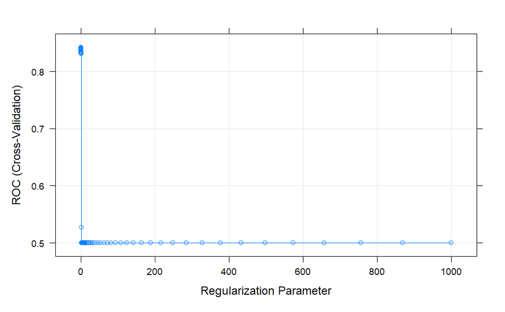

```r
plot(lasso)
```

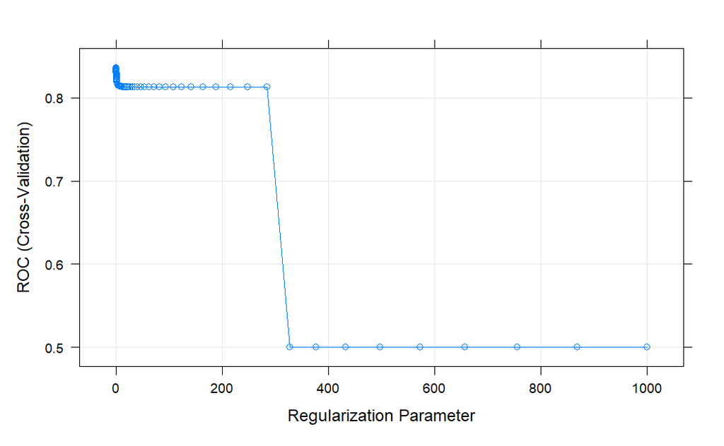

```r
plot(ridge)
```

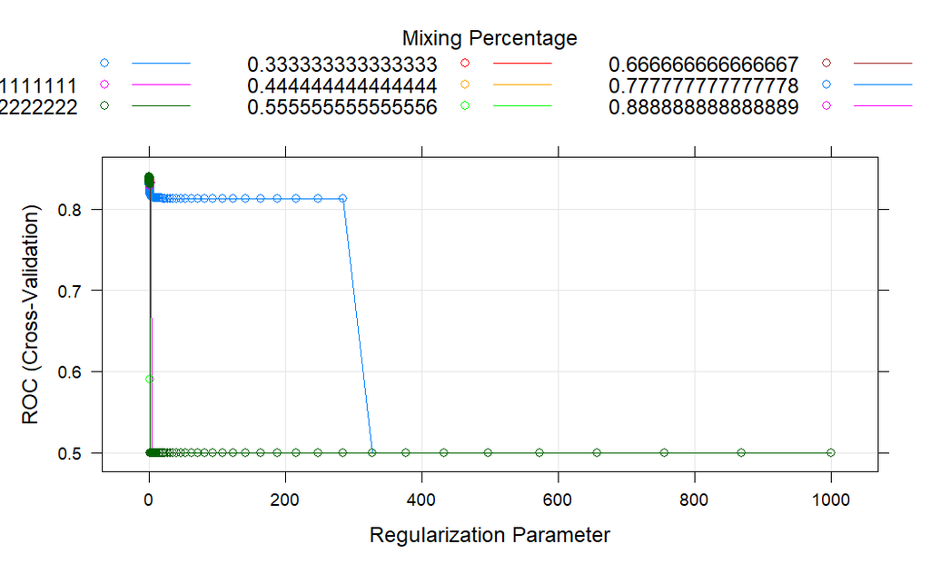

```r
plot(enet)
```

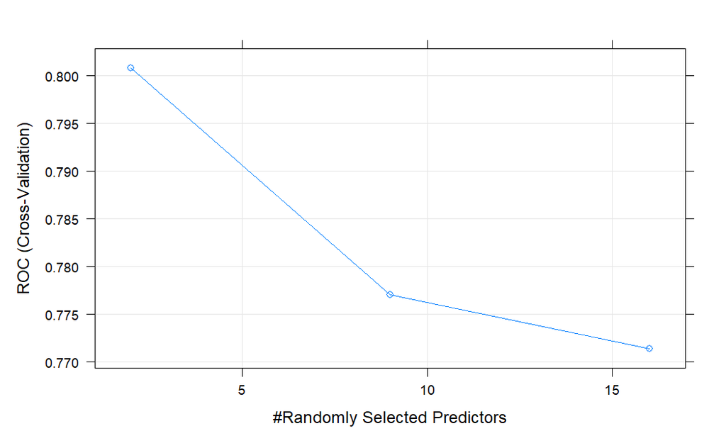

```r
plot(m_rf)
```

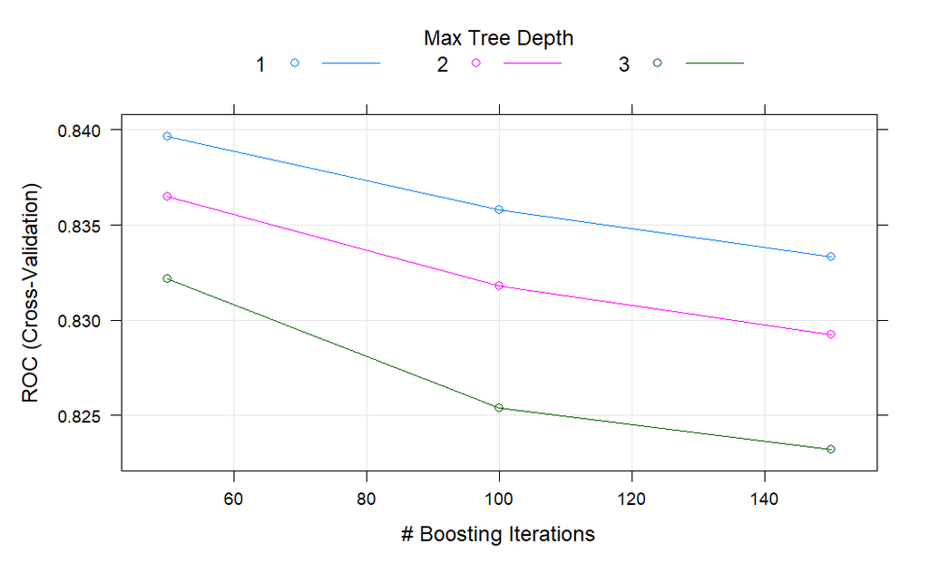

```r
plot(gbm)
```

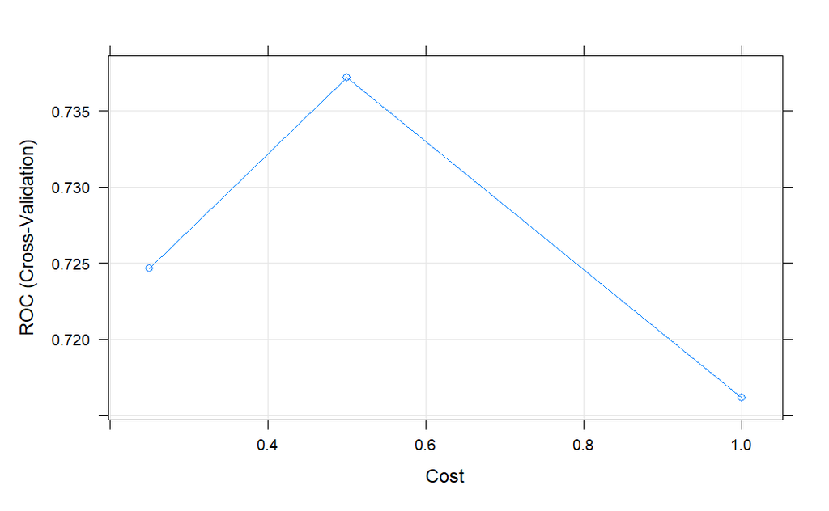

```r
plot(svm_rad)
```